# Deep Reinforcement Learning for football players' decisions evaluation

## Abstract

The evaluation of football player decision-making has traditionally relied on subjective metrics, often failing to capture the contextual nuances of the game. This project addresses the need for a more objective and comprehensive method by leveraging Deep Reinforcement Learning (DRL) to develop a Decision Value (DV) model. The problem lies in the limitations of existing models, such as Possession Value Models (PVMs), which lack contextual understanding. Inspired by Pulis (2023), our solution aims to emulate and extend his DV approach, despite facing computational constraints. Our findings indicate that while DVs do not consistently correlate with team performance or match outcomes, they provide valuable insights into individual decision-making. The model showed promise in identifying players making better decisions, particularly in specific scenarios. By addressing these challenges and refining our methodology, we contribute to the development of more accurate and insightful tools for football analysis.

1. Introduction

2. Literature Review * 2.1 Summary of Pulis (2023) * 2.2 Decision Making Analysis in Sport * 2.3 Football Decision Analysis * 2.4 Machine Learning in Football Analysis * 2.5 Reinforcement Learning in Sports Analysis * 2.6 Reinforcement Learning in Football

[output not shown]

3. Methodology
   - 3.1 Objectives
   - 3.2 Data Collection and Augmentation
     - 3.2.1 Dataset extraction
     - 3.2.2 Dataset exploration
   - 3.3 Models implementation
     - 3.3.1 AWAC
     - 3.3.2 IQL
4. Results
   - 4.1 Preliminary results
   - 4.2 MVP Analysis
   - 4.3 DVs of different potential actions
   - 4.4 Goalkeeper Analysis
   - 4.5 Cross/Pass Analysis
5. Discussion
   - 5.1 Interpretation of Results
   - 5.2 Limitations and Further Research
6. Conclusion

7. References

# 1. Introduction

In the realm of football analysis, the evaluation of player decision-making has historically been subjective, relying on easily interpretable statistics such as goals scored and assists provided. However, these metrics often overlook nuanced high-level performances and fail to account for the contextual complexities of the game. Recent advances in statistical analysis, including Expected Goals (xG) and Expected Threat (xT) (Singh, 2018) [1], have provided more objective metrics to address this issue. Nevertheless, existing models like Possession Value Models (PVMs) often lack the contextual understanding necessary to evaluate player decisions accurately.

Inspired by the work of Pulis (2023) [2], which proposed a novel Decision Value (DV) model using Deep Reinforcement Learning (DRL), our research seeks to emulate and extend this approach. Despite computational constraints limiting the scale of our study, we have made significant progress in emulating Pulis' methodology. Notably, our MVP function aligns closely with player performance rankings from established football analysis sources, demonstrating promise in objectively evaluating player decisions. Moreover, our findings closely mirror three key analyses conducted in the referenced paper, revealing a noteworthy positive correlation between decision values of passes and crosses for specific players. Additionally, by isolating distinct game states and comparing decision values across various actions, our model demonstrates consistency with expected behavior. Furthermore, our results align with the goalkeeper analysis presented in the paper, highlighting how decision values can effectively evaluate goalkeeper performance under different scenarios.

#### Research question

How can Deep Reinforcement Learning be leveraged to objectively evaluate football player decisions within the context of a match?

#### Structure of the report

This report is structured to comprehensively analyze the application of reinforcement learning (RL) in evaluating football player decisions. In Chapter 2, the Literature Review, we summarize key works, including Pulis (2023), and explore decision making, machine learning, and RL in football. In Chapter 3, the Methodology, we outline our objectives, detail the data collection and augmentation process, and explain the implementation of the AWAC and IQL models, along with our evaluation methods. In Chapter 4, the Results, we present our findings, covering preliminary results, MVP analysis, decision values of potential actions, goalkeeper analysis, and cross/pass analysis. In Chapter 5, the Discussion, we interpret the results, discuss limitations, and suggest further research directions. The report concludes with a Conclusion summarizing the key outcomes and their implications.

## 2. Literature Review

This section offers a comprehensive review of literature encompassing fundamental works and recent contributions on decision making, machine learning (ML) and reinforcement learning (RL) applied to football analysis. Furthermore, a brief summary of Pulis (2023) is provided.

#### 2.1 Summary of Pulis (2023)

Pulis (2023) explores the development of a Player Valuation Model (PVM) in football using Deep Reinforcement Learning (DRL) to account for the context of player decisions during games. The study aimed to generate a comprehensive dataset, implement a DRL model, and develop an evaluation metric for player decision-making. By using the StatsBomb Open Data, which includes paired event and tracking data from the English Premier League, the research created an augmented dataset formatted as images to capture various aspects of the game. The DRL model, trained using the d3rlpy library, employed the Implicit Q-Learning (IQL) algorithm due to its optimal performance. This model showed a high correlation with actual league standings, outperforming traditional metrics like expected goals (xG) and expected threat (xT), thereby demonstrating its effectiveness in evaluating player decisions and team performance.

The study highlights key contributions, such as the creation of a DRL-suited dataset and the development of a new, more accurate metric for evaluating player decisions. However, it also notes limitations, including the use of limited tracking data from broadcast cameras and the exclusion of certain game rules and actions. Future research directions suggest incorporating more detailed data on player velocities and identities, and expanding the range of considered actions to enhance model accuracy. Overall, Pulis (2023) provides a significant advancement in sports analytics, offering valuable insights and improving upon traditional evaluation methods by effectively considering the context of player actions.

#### 2.2 Decision Making Analysis in Sport

Decision making is a complex process, described as intentional, consequential, and optimizing (Chia, 1994; March, 1989) [3] . Gréhaigne et al. (2012) [4] identified crucial aspects of decision making in sports, including individual factors (player location, tactical knowledge, ability, and experience) and team-level factors (team tactics and cohesion). Vaeyens et al. (2007) [5] highlighted that higher-level players observe their environment more effectively. Woods et al. (2015) [6] found elite-level Australian under-18 football players exhibited superior decision making compared to non-players, as evaluated by professional coaches. Pizarro et al. (2019) [7] demonstrated that coaching sessions improved futsal players' decision making.

#### 2.3 Football Decision Analysis

Rudd (2011) made a significant early contribution by using English Premier League match data to quantify players' contributions to goal-scoring opportunities. By creating a transition matrix of pitch zones and states, they identified actions that increased goal likelihood, highlighting key players in goal creation.

#### 2.4 Machine Learning in Football Analysis

Early applications of Machine Learning (ML) in football focused on handling big data and squad tactical analysis (Rein and Memmert, 2016) [8]. García-Aliaga et al. (2021) [9] used clustering to identify similar playing styles and player positions from event data, creating a performance metric (PlayeRank) correlating actions to game outcomes. Kusmakar et al. (2020) [10] applied ML to predict which team would take the next shot with 75.2% accuracy and developed player interaction networks.

#### 2.5 Reinforcement Learning in Sports Analysis

RL has been used to analyze player performance in hockey (Liu and Schulte, 2018) [11] and basketball (Yanai et al., 2022) [12]. Liu and Schulte (2018) used a DRL model with SARSA learning and an LSTM-based Q-function approximator to evaluate player impact in hockey, developing the Goal Impact Metric (GIM). Yanai et al. (2022) developed Q-Ball to evaluate basketball players' decision making using a DDPG model trained on event and tracking data.

#### 2.6 Reinforcement Learning in Football

Initial RL applications in football involved training physical robots (Riedmiller et al., 2009) [13] and virtual environments by Google (Kurach et al., 2019) [14]. RL has been applied to historic football event data to model player behavior as a Markov Decision Process (Van Roy et al., 2021) and to evaluate players’ decisions (Liu et al., 2020). Rahimian et al. (2021) [15] used a CNN-LSTM model with policy gradient techniques to propose alternative decisions in critical game moments, demonstrating the efficacy of offline DRL.

## 3. Methodology

This section describes the methodology used to develop the Player Valuation Model (PVM) through Deep Reinforcement Learning (DRL). The methodology comprises several stages: data collection and augmentation, model implementation and training, and evaluation of the developed model. Each stage is detailed below to provide a comprehensive understanding of the research process.

### 3.1 Objectives

The three main objectives of our work are:

1. Generating an augmented dataset suited for DRL using free existing football tracking and event analysis data.
2. Implementing a DRL model to learn to value football player decisions.
3. Evaluating the Decision Value (DV) metric obtained by our model with respect to our football knowledge and traditional statistics.

### 3.2 Data Collection and Augmentation

Data Source: The dataset used in this project was available on the open-data repository of StatsBomb (https://github.com/statsbomb/open-data), containing detailed event and tracking data from the 2022 FIFA World Cup, the 2020 UEFA Euro, the 2023 Women's World Cup and the 2022 UEFA Women's Euro. For this project, only the data about the 2020 UEFA Euro will be used. Below, the extraction and the selection of the initial dataset.

### 3.2.1 Dataset extraction

```python
import numpy as np
import pandas as pd
from socceraction.data.statsbomb import StatsBombLoader
import socceraction.spadl as spadl
import socceraction.xthreat as xthreat
import matplotlib.pyplot as plt
import matplotlib.patches as patches
import warnings
warnings.filterwarnings("ignore")
import os
from tqdm import tqdm
```

To begin generating the dataset for applying DRL techniques, we first need to load the original datasets from StatsBomb.

```python
api = StatsBombLoader(getter="local", root="/data")
```

Specifically, two datasets will be extracted: df_event and df_actions. The df_event dataset is a comprehensive dataset containing detailed event information, whereas df_actions is a subset obtained by applying the Soccer Player Action Description Language (SPADL) library to our data. The aim of the SPADL library is to obtain a universal protocol for describing football player actions (Pulis, 2023).

```python
df_event = pd.DataFrame()
df_actions = pd.DataFrame()
for filename in os.listdir('/data/three-sixty/'):
    if len(filename.split('.')[0]) > 4:
        """
        To generate the large df_event, we need to specify to the API that we only want games
        that have the 360 data (hence the argument below).
        This is done as we will need this 360 data (tracking data), as they will consitute the states of our model.
        """
        df_event = pd.concat([df_event, api.events(game_id = filename.split('.')[0], load_360 = True)], axis = 0)

        df_event.visible_area_360.fillna(method = 'ffill', inplace = True)
        df_event.freeze_frame_360.fillna(method = 'ffill', inplace = True)

        act = spadl.statsbomb.convert_to_actions(
            events=api.events(game_id = filename.split('.')[0]),
            home_team_id = api.teams(game_id=filename.split('.')[0]).iloc[0,0])

        # 2. Convert direction of play + add names
        act = pd.concat([
          spadl.play_left_to_right(act, api.teams(game_id=filename.split('.')[0]).iloc[0,0])
        ])
        act = spadl.add_names(act)

        df_actions = pd.concat([df_actions, act], axis = 0)
```

Below, an example of these data with a visualisation.

Below df_event, that gives information on all the events which have take place on all the matches that we have data on.

```python
df_event.to_parquet('df_event.parquet')
df_event = pd.read_parquet('df_event.parquet')
df_event
```

|  | game_id | event_id | period_id | team_id | player_id | type_id | type_name | index | timestamp | minute | ... | extra | related_events | player_name | position_id | position_name | location | under_pressure | counterpress | visible_area_360 | freeze_frame_360 |
| --- | --- | --- | --- | --- | --- | --- | --- | --- | --- | --- | --- | --- | --- | --- | --- | --- | --- | --- | --- | --- | --- |
| 0 | 3902240 | 61a65a75-ea09-4232-a790-546eba8b1b57 | 1 | 863 | NaN | 35 | Starting XI | 1 | 0 days 00:00:00 | 0 | ... | {'tactics': {'formation': 433, 'lineup': [{'pl... | [] | NaN | NaN | NaN | NaN | False | False | NaN | NaN |
| 1 | 3902240 | a34d89fe-a7ef-4b46-9bd4-7d41df5bb889 | 1 | 851 | NaN | 35 | Starting XI | 2 | 0 days 00:00:00 | 0 | ... | {'tactics': {'formation': 352, 'lineup': [{'pl... | [] | NaN | NaN | NaN | NaN | False | False | NaN | NaN |
| 2 | 3902240 | d168c0a8-70bc-4ce0-a80f-b3e5f868caca | 1 | 863 | NaN | 18 | Half Start | 3 | 0 days 00:00:00 | 0 | ... | {} | [c2113a2b-8949-423b-b9bd-2a18f894f8a0] | NaN | NaN | NaN | NaN | False | False | NaN | NaN |
| 3 | 3902240 | c2113a2b-8949-423b-b9bd-2a18f894f8a0 | 1 | 851 | NaN | 18 | Half Start | 4 | 0 days 00:00:00 | 0 | ... | {} | [d168c0a8-70bc-4ce0-a80f-b3e5f868caca] | NaN | NaN | NaN | NaN | False | False | NaN | NaN |
| 4 | 3902240 | 75d6cc25-b03b-44e0-9c50-99a7e3c47315 | 1 | 851 | 10649.0 | 30 | Pass | 5 | 0 days 00:00:00.443000 | 0 | ... | {'pass': {'recipient': {'id': 10656, 'name': '... | [ec457cc8-050c-4884-abbc-1e85bc3c83dc] | Lieke Martens | 24.0 | Left Center Forward | [61.0, 40.1] | False | False | [29.574167858721, 80.0, 47.7992071074168, 0.0,... | [{'teammate': True, 'actor': False, 'keeper': ... |
| ... | ... | ... | ... | ... | ... | ... | ... | ... | ... | ... | ... | ... | ... | ... | ... | ... | ... | ... | ... | ... | ... |
| 4985 | 3795108 | 8d952657-4b7f-498c-ac8a-7a92f8e0bced | 5 | 772 | 11748.0 | 23 | Goal Keeper | 4986 | 0 days 00:05:54.582000 | 125 | ... | {'goalkeeper': {'position': {'id': 44, 'name':... | [74766d37-8c9c-4317-8edf-97eede1b0242] | Unai Simón Mendibil | 1.0 | Goalkeeper | [1.0, 40.0] | False | False | [0.0, 80.0, 0.0, 17.9706513596314, 15.98134790... | [{'teammate': True, 'actor': True, 'keeper': T... |
| 4986 | 3795108 | 5071ddf9-c034-47db-b115-0feb791e9ee4 | 5 | 772 | 6685.0 | 16 | Shot | 4987 | 0 days 00:07:04.301000 | 127 | ... | {'shot': {'one_on_one': True, 'statsbomb_xg': ... | [98257d23-84a8-4a2e-94f2-dea542e5aece] | Mikel Oyarzabal Ugarte | 17.0 | Right Wing | [108.0, 40.0] | False | False | [0.0, 80.0, 0.0, 17.9706513596314, 15.98134790... | [{'teammate': True, 'actor': True, 'keeper': T... |
| 4987 | 3795108 | 98257d23-84a8-4a2e-94f2-dea542e5aece | 5 | 773 | 5550.0 | 23 | Goal Keeper | 4988 | 0 days 00:07:04.869000 | 127 | ... | {'goalkeeper': {'type': {'id': 28, 'name': 'Pe... | [5071ddf9-c034-47db-b115-0feb791e9ee4] | Yann Sommer | 1.0 | Goalkeeper | [1.0, 40.0] | False | False | [0.0, 80.0, 0.0, 17.9706513596314, 15.98134790... | [{'teammate': True, 'actor': True, 'keeper': T... |
| 4988 | 3795108 | bc0d4cb2-b0f9-4608-bd0a-4de3719cf6d6 | 5 | 772 | NaN | 34 | Half End | 4989 | 0 days 00:07:05.592000 | 127 | ... | {} | [b537892f-2dc4-4fda-bccf-494b82408b2c] | NaN | NaN | NaN | NaN | False | False | [0.0, 80.0, 0.0, 17.9706513596314, 15.98134790... | [{'teammate': True, 'actor': True, 'keeper': T... |
| 4989 | 3795108 | b537892f-2dc4-4fda-bccf-494b82408b2c | 5 | 773 | NaN | 34 | Half End | 4990 | 0 days 00:07:05.592000 | 127 | ... | {} | [bc0d4cb2-b0f9-4608-bd0a-4de3719cf6d6] | NaN | NaN | NaN | NaN | False | False | [0.0, 80.0, 0.0, 17.9706513596314, 15.98134790... | [{'teammate': True, 'actor': True, 'keeper': T... |

748970 rows × 28 columns

Below, df_actions. Similarly to df_events, this dataframe gives us information on the events that take place in all the football matches we have. However, it differs from df_events because it shows only the actual actions which took place in games. Therefore, each row of df_actions corresponds to an action which took place in the game (e.g. the 4th row corresponds to a failed pass).

```python
df_actions.to_parquet('df_actions.parquet')
df_actions = pd.read_parquet('df_actions.parquet')
df_actions
```

|  | game_id | original_event_id | period_id | time_seconds | team_id | player_id | start_x | start_y | end_x | end_y | type_id | result_id | bodypart_id | action_id | type_name | result_name | bodypart_name |
| --- | --- | --- | --- | --- | --- | --- | --- | --- | --- | --- | --- | --- | --- | --- | --- | --- | --- |
| 0 | 3902240 | 75d6cc25-b03b-44e0-9c50-99a7e3c47315 | 1 | 0.443 | 851 | 10649.0 | 53.33125 | 33.9575 | 52.80625 | 31.4075 | 0 | 1 | 5 | 0 | pass | success | foot_right |
| 1 | 3902240 | 246b93aa-3831-4b07-a51e-b6ba578e60d5 | 1 | 0.867 | 851 | 10656.0 | 51.58125 | 33.2775 | 31.10625 | 25.5425 | 0 | 1 | 5 | 1 | pass | success | foot_right |
| 2 | 3902240 | e8a3f021-76da-443b-9a1d-c5857c486493 | 1 | 2.630 | 851 | 10645.0 | 31.10625 | 25.5425 | 30.49375 | 24.7775 | 21 | 1 | 0 | 2 | dribble | success | foot |
| 3 | 3902240 | 3d4522df-ff5f-4aac-98d3-7437e844d12f | 1 | 4.111 | 851 | 10645.0 | 30.49375 | 24.7775 | 68.99375 | 13.6425 | 0 | 0 | 5 | 3 | pass | fail | foot_right |
| 4 | 3902240 | a866dfc1-a61a-4a46-bd83-86e8de9c0d69 | 1 | 6.346 | 863 | 49835.0 | 36.00625 | 54.3575 | 27.95625 | 65.1525 | 0 | 1 | 1 | 4 | pass | success | head |
| ... | ... | ... | ... | ... | ... | ... | ... | ... | ... | ... | ... | ... | ... | ... | ... | ... | ... |
| 2982 | 3795108 | 5ee73781-dd19-4c9b-b3ff-7517eb7314ca | 5 | 201.489 | 772 | 6765.0 | 94.45625 | 34.0425 | 104.43125 | 32.0025 | 12 | 0 | 5 | 2982 | shot_penalty | fail | foot_right |
| 2983 | 3795108 | d28b5cca-de81-4782-a11f-41fa3b5bf059 | 5 | 265.619 | 773 | 5549.0 | 94.45625 | 34.0425 | 104.08125 | 36.2525 | 12 | 0 | 5 | 2983 | shot_penalty | fail | foot_right |
| 2984 | 3795108 | 6d362616-fa4c-446a-94e5-62ee59015f16 | 5 | 307.463 | 772 | 6766.0 | 94.45625 | 34.0425 | 104.95625 | 31.0675 | 12 | 1 | 4 | 2984 | shot_penalty | success | foot_left |
| 2985 | 3795108 | 74766d37-8c9c-4317-8edf-97eede1b0242 | 5 | 354.063 | 773 | 30401.0 | 94.45625 | 34.0425 | 104.95625 | 35.1475 | 12 | 0 | 5 | 2985 | shot_penalty | fail | foot_right |
| 2986 | 3795108 | 5071ddf9-c034-47db-b115-0feb791e9ee4 | 5 | 424.301 | 772 | 6685.0 | 94.45625 | 34.0425 | 104.95625 | 31.2375 | 12 | 1 | 4 | 2986 | shot_penalty | success | foot_left |

433100 rows × 17 columns

Below, the missing data in the original_event_id column. These actions are generated by the SPADL library to connect actions that otherwise would remain unconnected. In fact, successful dribbles (movements of a player carrying the ball from place to another) are added without an original_event_id, meaning that these events are not recorded in the original dataset.

This fact could be an issue for us when we will need to generate the states for each row. Indeed, in order to pin down the state for any row we need to know what its original_event_id is. To go around this, we generate artifical event ids, called pc_id, which are the same as the original_event_id for all rows that aren't missing original_event_id, and are the previous row's original_event_id if the current row has a missing original_event_id.

```python
df_actions[pd.isna(df_actions.original_event_id)]
```

|  | game_id | original_event_id | period_id | time_seconds | team_id | player_id | start_x | start_y | end_x | end_y | type_id | result_id | bodypart_id | action_id | type_name | result_name | bodypart_name |
| --- | --- | --- | --- | --- | --- | --- | --- | --- | --- | --- | --- | --- | --- | --- | --- | --- | --- |
| 90 | 3902240 | NaN | 1 | 203.6900 | 863 | 10161.0 | 44.05625 | 61.9225 | 50.00625 | 64.7275 | 21 | 1 | 0 | 90 | dribble | success | foot |
| 104 | 3902240 | NaN | 1 | 271.3600 | 863 | 15284.0 | 57.61875 | 55.5475 | 46.59375 | 55.5475 | 21 | 1 | 0 | 104 | dribble | success | foot |
| 117 | 3902240 | NaN | 1 | 307.5825 | 851 | 10645.0 | 13.43125 | 16.9575 | 9.31875 | 17.0425 | 21 | 1 | 0 | 117 | dribble | success | foot |
| 143 | 3902240 | NaN | 1 | 381.2440 | 863 | 49835.0 | 35.21875 | 56.4825 | 38.54375 | 56.9075 | 21 | 1 | 0 | 143 | dribble | success | foot |
| 156 | 3902240 | NaN | 1 | 453.3305 | 851 | 62962.0 | 53.94375 | 62.0925 | 61.20625 | 60.2225 | 21 | 1 | 0 | 156 | dribble | success | foot |
| ... | ... | ... | ... | ... | ... | ... | ... | ... | ... | ... | ... | ... | ... | ... | ... | ... | ... |
| 2681 | 3795108 | NaN | 4 | 212.4640 | 773 | 16027.0 | 7.65625 | 2.2525 | 3.54375 | 3.5275 | 21 | 1 | 0 | 2681 | dribble | success | foot |
| 2794 | 3795108 | NaN | 4 | 519.9120 | 772 | 5211.0 | 18.76875 | 63.7075 | 19.29375 | 60.4775 | 21 | 1 | 0 | 2794 | dribble | success | foot |
| 2866 | 3795108 | NaN | 4 | 697.7060 | 773 | 5537.0 | 79.31875 | 14.6625 | 75.20625 | 16.7875 | 21 | 1 | 0 | 2866 | dribble | success | foot |
| 2874 | 3795108 | NaN | 4 | 710.2500 | 772 | 5211.0 | 38.36875 | 63.5375 | 31.63125 | 67.9575 | 21 | 1 | 0 | 2874 | dribble | success | foot |
| 2969 | 3795108 | NaN | 4 | 945.8430 | 772 | 5208.0 | 56.30625 | 46.4525 | 64.61875 | 47.8975 | 21 | 1 | 0 | 2969 | dribble | success | foot |

9850 rows × 17 columns

```python
df_actions['pc_id'] = df_actions.iloc[:,1]
df_actions['pc_id'].fillna(method = 'ffill', inplace = True)
df_actions
```

|  | game_id | original_event_id | period_id | time_seconds | team_id | player_id | start_x | start_y | end_x | end_y | type_id | result_id | bodypart_id | action_id | type_name | result_name | bodypart_name | pc_id |
| --- | --- | --- | --- | --- | --- | --- | --- | --- | --- | --- | --- | --- | --- | --- | --- | --- | --- | --- |
| 0 | 3902240 | 75d6cc25-b03b-44e0-9c50-99a7e3c47315 | 1 | 0.443 | 851 | 10649.0 | 53.33125 | 33.9575 | 52.80625 | 31.4075 | 0 | 1 | 5 | 0 | pass | success | foot_right | 75d6cc25-b03b-44e0-9c50-99a7e3c47315 |
| 1 | 3902240 | 246b93aa-3831-4b07-a51e-b6ba578e60d5 | 1 | 0.867 | 851 | 10656.0 | 51.58125 | 33.2775 | 31.10625 | 25.5425 | 0 | 1 | 5 | 1 | pass | success | foot_right | 246b93aa-3831-4b07-a51e-b6ba578e60d5 |
| 2 | 3902240 | e8a3f021-76da-443b-9a1d-c5857c486493 | 1 | 2.630 | 851 | 10645.0 | 31.10625 | 25.5425 | 30.49375 | 24.7775 | 21 | 1 | 0 | 2 | dribble | success | foot | e8a3f021-76da-443b-9a1d-c5857c486493 |
| 3 | 3902240 | 3d4522df-ff5f-4aac-98d3-7437e844d12f | 1 | 4.111 | 851 | 10645.0 | 30.49375 | 24.7775 | 68.99375 | 13.6425 | 0 | 0 | 5 | 3 | pass | fail | foot_right | 3d4522df-ff5f-4aac-98d3-7437e844d12f |
| 4 | 3902240 | a866dfc1-a61a-4a46-bd83-86e8de9c0d69 | 1 | 6.346 | 863 | 49835.0 | 36.00625 | 54.3575 | 27.95625 | 65.1525 | 0 | 1 | 1 | 4 | pass | success | head | a866dfc1-a61a-4a46-bd83-86e8de9c0d69 |
| ... | ... | ... | ... | ... | ... | ... | ... | ... | ... | ... | ... | ... | ... | ... | ... | ... | ... | ... |
| 2982 | 3795108 | 5ee73781-dd19-4c9b-b3ff-7517eb7314ca | 5 | 201.489 | 772 | 6765.0 | 94.45625 | 34.0425 | 104.43125 | 32.0025 | 12 | 0 | 5 | 2982 | shot_penalty | fail | foot_right | 5ee73781-dd19-4c9b-b3ff-7517eb7314ca |
| 2983 | 3795108 | d28b5cca-de81-4782-a11f-41fa3b5bf059 | 5 | 265.619 | 773 | 5549.0 | 94.45625 | 34.0425 | 104.08125 | 36.2525 | 12 | 0 | 5 | 2983 | shot_penalty | fail | foot_right | d28b5cca-de81-4782-a11f-41fa3b5bf059 |
| 2984 | 3795108 | 6d362616-fa4c-446a-94e5-62ee59015f16 | 5 | 307.463 | 772 | 6766.0 | 94.45625 | 34.0425 | 104.95625 | 31.0675 | 12 | 1 | 4 | 2984 | shot_penalty | success | foot_left | 6d362616-fa4c-446a-94e5-62ee59015f16 |
| 2985 | 3795108 | 74766d37-8c9c-4317-8edf-97eede1b0242 | 5 | 354.063 | 773 | 30401.0 | 94.45625 | 34.0425 | 104.95625 | 35.1475 | 12 | 0 | 5 | 2985 | shot_penalty | fail | foot_right | 74766d37-8c9c-4317-8edf-97eede1b0242 |
| 2986 | 3795108 | 5071ddf9-c034-47db-b115-0feb791e9ee4 | 5 | 424.301 | 772 | 6685.0 | 94.45625 | 34.0425 | 104.95625 | 31.2375 | 12 | 1 | 4 | 2986 | shot_penalty | success | foot_left | 5071ddf9-c034-47db-b115-0feb791e9ee4 |

433100 rows × 18 columns

In this wat no rows have NaN for pc_id.

```python
df_actions[pd.isna(df_actions.pc_id)]
```

|  | game_id | original_event_id | period_id | time_seconds | team_id | player_id | start_x | start_y | end_x | end_y | type_id | result_id | bodypart_id | action_id | type_name | result_name | bodypart_name | pc_id |
| --- | --- | --- | --- | --- | --- | --- | --- | --- | --- | --- | --- | --- | --- | --- | --- | --- | --- | --- |

Furthermore, we seek to eliminate the presence of NaNs in original_event_id. Doing so will prevent us from mapping a state to any of rows with missing original_event_id.

```python
k = 0
for i in range(len(df_actions)):
    if pd.isna(df_actions.iloc[i,1]):
        df_actions.iloc[i,1] = str(k)
        k += 1
```

For the purpose of this project we are going to focus on the following actions: pass, dribble, clearence, shot and cross. A dribble is a movement of a player with the ball, carrying it from one location to another without possibilities of losing the possession because of the intervention of an opponent.

```python
actions = ['pass', 'dribble', 'clearance', 'shot', 'cross']
df_actions = df_actions[df_actions.type_name.isin(actions)]
```

```python
df_actions
```

[output not shown]

```python
df_actions.to_parquet('df_actions_clean.parquet')
df_actions = pd.read_parquet('df_actions_clean.parquet')
```

Finally, an example of these data with a visualisation.

```python
example
```

[output not shown]

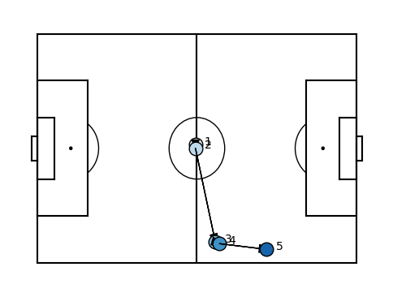

```python
import matplotsoccer

ax = matplotsoccer.actions(
    location=df_actions.iloc[0:5][["end_x", "end_y"]],
    zoom=False,
    figsize=6
)
```

### 3.2.2 Dataset exploration

Below all the matches that are contained in the dataset.

```python
list_competitions = list(api.competitions()['competition_id'].unique())

df_comp_seasons = pd.DataFrame(columns=['competition_id','season_id','game_id'])

for comp in list_competitions:
    for season in list(api.competitions()[api.competitions()['competition_id'] == comp]['season_id']):
        df_comp_seasons = pd.concat([df_comp_seasons,api.games(competition_id=comp, season_id=season)[['competition_id','season_id','game_id']]])

game_comp = pd.DataFrame(columns = ['game_id', 'competition_id','season_id'])

for game in df_actions['game_id'].unique():
    game_comp.loc[len(game_comp)] = [int(game), df_comp_seasons[df_comp_seasons['game_id'] == int(game)].iloc[0,0], df_comp_seasons[df_comp_seasons['game_id'] == int(game)].iloc[0,1]]

game_comp
```

|  | game_id | competition_id | season_id |
| --- | --- | --- | --- |
| 0 | 3902240 | 72 | 107 |
| 1 | 3788742 | 55 | 43 |
| 2 | 3893798 | 72 | 107 |
| 3 | 3869354 | 43 | 106 |
| 4 | 3893809 | 72 | 107 |
| ... | ... | ... | ... |
| 202 | 3893830 | 72 | 107 |
| 203 | 3857268 | 43 | 106 |
| 204 | 3795221 | 55 | 43 |
| 205 | 3844385 | 53 | 106 |
| 206 | 3795108 | 55 | 43 |

207 rows × 3 columns

We can use the competition_id and season_id columns from the game_comp data frame to get a breakdown of the matches according to competition and season.

```python
game_comp.competition_id.value_counts()
```

```
competition_id
72    64
43    64
55    51
53    28
Name: count, dtype: int64
```

```python
game_comp.season_id.value_counts()
```

```
season_id
106    92
107    64
43     51
Name: count, dtype: int64
```

Below, the names of the competitions on which we have event and tracking data:

```python
api.competitions()[api.competitions().competition_id == 53]
```

|  | season_id | competition_id | competition_name | country_name | competition_gender | season_name |
| --- | --- | --- | --- | --- | --- | --- |
| 68 | 106 | 53 | UEFA Women's Euro | Europe | female | 2022 |

```python
api.competitions()[(api.competitions().competition_id == 43) & (api.competitions().season_id == 106)]
```

|  | season_id | competition_id | competition_name | country_name | competition_gender | season_name |
| --- | --- | --- | --- | --- | --- | --- |
| 27 | 106 | 43 | FIFA World Cup | International | male | 2022 |

```python
api.competitions()[api.competitions().competition_id == 55]
```

|  | season_id | competition_id | competition_name | country_name | competition_gender | season_name |
| --- | --- | --- | --- | --- | --- | --- |
| 66 | 43 | 55 | UEFA Euro | Europe | male | 2020 |

```python
api.competitions()[(api.competitions().competition_id == 72) & (api.competitions().season_id == 107)]
```

|  | season_id | competition_id | competition_name | country_name | competition_gender | season_name |
| --- | --- | --- | --- | --- | --- | --- |
| 69 | 107 | 72 | Women's World Cup | International | female | 2023 |

## EURO 2020

Here we isolate all the matches from our data set which come from EURO 2020.

```python
euro2020 = api.games(competition_id = 55, season_id = 43)
euro2020['home_team'] = 0
euro2020['away_team'] = 0

for i in range(len(euro2020)):
    row = euro2020.iloc[i]
    match_id = row.game_id
    df = api.teams(game_id = str(match_id))
    euro2020.iloc[i,-2] = df[df.team_id == row.home_team_id].iloc[0,1]
    euro2020.iloc[i,-1] = df[df.team_id == row.away_team_id].iloc[0,1]

euro2020
```

|  | game_id | season_id | competition_id | competition_stage | game_day | game_date | home_team_id | away_team_id | home_score | away_score | venue | referee | home_team | away_team |
| --- | --- | --- | --- | --- | --- | --- | --- | --- | --- | --- | --- | --- | --- | --- |
| 0 | 3795108 | 43 | 55 | Quarter-finals | 5 | 2021-07-02 18:00:00 | 773 | 772 | 1 | 1 | Saint-Petersburg Stadium | Michael Oliver | Switzerland | Spain |
| 1 | 3788769 | 43 | 55 | Group Stage | 3 | 2021-06-21 21:00:00 | 796 | 776 | 1 | 4 | Parken | Clément Turpin | Russia | Denmark |
| 2 | 3788766 | 43 | 55 | Group Stage | 3 | 2021-06-20 18:00:00 | 914 | 907 | 1 | 0 | Estadio Olímpico | Ovidiu Alin Hațegan | Italy | Wales |
| 3 | 3795220 | 43 | 55 | Semi-finals | 6 | 2021-07-06 21:00:00 | 914 | 772 | 1 | 1 | Wembley Stadium | Felix Brych | Italy | Spain |
| 4 | 3788761 | 43 | 55 | Group Stage | 2 | 2021-06-18 15:00:00 | 790 | 908 | 1 | 0 | Saint-Petersburg Stadium | Daniel Siebert | Sweden | Slovakia |
| 5 | 3788764 | 43 | 55 | Group Stage | 2 | 2021-06-19 18:00:00 | 780 | 770 | 2 | 4 | Allianz Arena | Anthony Taylor | Portugal | Germany |
| 6 | 3788773 | 43 | 55 | Group Stage | 3 | 2021-06-23 21:00:00 | 780 | 771 | 2 | 2 | Puskás Aréna | Antonio Miguel Mateu Lahoz | Portugal | France |
| 7 | 3788755 | 43 | 55 | Group Stage | 2 | 2021-06-16 18:00:00 | 909 | 907 | 0 | 2 | Bakı Olimpiya Stadionu | Artur Manuel Ribeiro Soares Dias | Turkey | Wales |
| 8 | 3788754 | 43 | 55 | Group Stage | 2 | 2021-06-16 21:00:00 | 914 | 773 | 3 | 0 | Estadio Olímpico | Sergey Karasev | Italy | Switzerland |
| 9 | 3788762 | 43 | 55 | Group Stage | 2 | 2021-06-19 21:00:00 | 772 | 789 | 1 | 1 | Estadio de La Cartuja | Daniele Orsato | Spain | Poland |
| 10 | 3788760 | 43 | 55 | Group Stage | 2 | 2021-06-18 18:00:00 | 785 | 912 | 1 | 1 | Hampden Park | Carlos del Cerro Grande | Croatia | Czech Republic |
| 11 | 3788747 | 43 | 55 | Group Stage | 1 | 2021-06-13 18:00:00 | 915 | 2358 | 3 | 1 | Arena Naţională | Lars Christian Andreas Ekberg | Austria | North Macedonia |
| 12 | 3788741 | 43 | 55 | Group Stage | 1 | 2021-06-11 21:00:00 | 909 | 914 | 0 | 3 | Estadio Olímpico | Danny Desmond Makkelie | Turkey | Italy |
| 13 | 3795109 | 43 | 55 | Quarter-finals | 5 | 2021-07-03 18:00:00 | 912 | 776 | 1 | 2 | Bakı Olimpiya Stadionu | Björn Kuipers | Czech Republic | Denmark |
| 14 | 3795187 | 43 | 55 | Quarter-finals | 5 | 2021-07-03 21:00:00 | 911 | 768 | 0 | 4 | Estadio Olímpico | Felix Brych | Ukraine | England |
| 15 | 3788770 | 43 | 55 | Group Stage | 3 | 2021-06-21 18:00:00 | 2358 | 941 | 0 | 3 | Johan Cruijff Arena (Amsterdam) | Istvan Kovacs | North Macedonia | Netherlands |
| 16 | 3795506 | 43 | 55 | Final | 7 | 2021-07-11 21:00:00 | 914 | 768 | 1 | 1 | Wembley Stadium | Björn Kuipers | Italy | England |
| 17 | 3794688 | 43 | 55 | Round of 16 | 4 | 2021-06-29 18:00:00 | 768 | 770 | 2 | 0 | Wembley Stadium | Danny Desmond Makkelie | England | Germany |
| 18 | 3794692 | 43 | 55 | Round of 16 | 4 | 2021-06-29 21:00:00 | 790 | 911 | 1 | 2 | Hampden Park | Daniele Orsato | Sweden | Ukraine |
| 19 | 3794686 | 43 | 55 | Round of 16 | 4 | 2021-06-28 18:00:00 | 785 | 772 | 3 | 5 | Parken | Cüneyt Çakιr | Croatia | Spain |
| 20 | 3794687 | 43 | 55 | Round of 16 | 4 | 2021-06-27 21:00:00 | 782 | 780 | 1 | 0 | Estadio de La Cartuja | Felix Brych | Belgium | Portugal |
| 21 | 3794685 | 43 | 55 | Round of 16 | 4 | 2021-06-26 21:00:00 | 914 | 915 | 2 | 1 | Wembley Stadium | Anthony Taylor | Italy | Austria |
| 22 | 3788774 | 43 | 55 | Group Stage | 3 | 2021-06-23 21:00:00 | 770 | 916 | 2 | 2 | Allianz Arena | Sergey Karasev | Germany | Hungary |
| 23 | 3788771 | 43 | 55 | Group Stage | 3 | 2021-06-22 21:00:00 | 785 | 942 | 3 | 1 | Hampden Park | Fernando Andrés Rapallini | Croatia | Scotland |
| 24 | 3788772 | 43 | 55 | Group Stage | 3 | 2021-06-22 21:00:00 | 912 | 768 | 0 | 1 | Wembley Stadium | Artur Manuel Ribeiro Soares Dias | Czech Republic | England |
| 25 | 3788768 | 43 | 55 | Group Stage | 3 | 2021-06-21 21:00:00 | 1835 | 782 | 0 | 2 | Saint-Petersburg Stadium | Felix Brych | Finland | Belgium |
| 26 | 3788767 | 43 | 55 | Group Stage | 3 | 2021-06-21 18:00:00 | 911 | 915 | 0 | 1 | Arena Naţională | Cüneyt Çakιr | Ukraine | Austria |
| 27 | 3788753 | 43 | 55 | Group Stage | 2 | 2021-06-16 15:00:00 | 1835 | 796 | 0 | 1 | Saint-Petersburg Stadium | Danny Desmond Makkelie | Finland | Russia |
| 28 | 3788765 | 43 | 55 | Group Stage | 3 | 2021-06-20 18:00:00 | 773 | 909 | 3 | 1 | Bakı Olimpiya Stadionu | Slavko Vinčić | Switzerland | Turkey |
| 29 | 3788763 | 43 | 55 | Group Stage | 2 | 2021-06-19 15:00:00 | 916 | 771 | 1 | 1 | Puskás Aréna | Michael Oliver | Hungary | France |
| 30 | 3788759 | 43 | 55 | Group Stage | 2 | 2021-06-18 21:00:00 | 768 | 942 | 0 | 0 | Wembley Stadium | Antonio Miguel Mateu Lahoz | England | Scotland |
| 31 | 3788758 | 43 | 55 | Group Stage | 2 | 2021-06-17 15:00:00 | 911 | 2358 | 2 | 1 | Arena Naţională | Fernando Andrés Rapallini | Ukraine | North Macedonia |
| 32 | 3788757 | 43 | 55 | Group Stage | 2 | 2021-06-17 18:00:00 | 776 | 782 | 1 | 2 | Parken | Björn Kuipers | Denmark | Belgium |
| 33 | 3788745 | 43 | 55 | Group Stage | 1 | 2021-06-13 15:00:00 | 768 | 785 | 1 | 0 | Wembley Stadium | Daniele Orsato | England | Croatia |
| 34 | 3795107 | 43 | 55 | Quarter-finals | 5 | 2021-07-02 21:00:00 | 782 | 914 | 1 | 2 | Allianz Arena | Slavko Vinčić | Belgium | Italy |
| 35 | 3795221 | 43 | 55 | Semi-finals | 6 | 2021-07-07 21:00:00 | 768 | 776 | 2 | 1 | Wembley Stadium | Danny Desmond Makkelie | England | Denmark |
| 36 | 3794689 | 43 | 55 | Round of 16 | 4 | 2021-06-26 18:00:00 | 907 | 776 | 0 | 4 | Johan Cruijff Arena (Amsterdam) | Daniel Siebert | Wales | Denmark |
| 37 | 3788746 | 43 | 55 | Group Stage | 1 | 2021-06-13 21:00:00 | 941 | 911 | 3 | 2 | Johan Cruijff Arena (Amsterdam) | Felix Brych | Netherlands | Ukraine |
| 38 | 3794691 | 43 | 55 | Round of 16 | 4 | 2021-06-28 21:00:00 | 771 | 773 | 3 | 3 | Arena Naţională | Fernando Andrés Rapallini | France | Switzerland |
| 39 | 3794690 | 43 | 55 | Round of 16 | 4 | 2021-06-27 18:00:00 | 941 | 912 | 0 | 2 | Puskás Aréna | Sergey Karasev | Netherlands | Czech Republic |
| 40 | 3788756 | 43 | 55 | Group Stage | 2 | 2021-06-17 21:00:00 | 941 | 915 | 2 | 0 | Johan Cruijff Arena (Amsterdam) | Orel Grinfeeld | Netherlands | Austria |
| 41 | 3788749 | 43 | 55 | Group Stage | 1 | 2021-06-14 18:00:00 | 789 | 908 | 1 | 2 | Saint-Petersburg Stadium | Ovidiu Alin Hațegan | Poland | Slovakia |
| 42 | 3788750 | 43 | 55 | Group Stage | 1 | 2021-06-14 21:00:00 | 772 | 790 | 0 | 0 | Estadio de La Cartuja | Slavko Vinčić | Spain | Sweden |
| 43 | 3788748 | 43 | 55 | Group Stage | 1 | 2021-06-14 15:00:00 | 942 | 912 | 0 | 2 | Hampden Park | Daniel Siebert | Scotland | Czech Republic |
| 44 | 3788751 | 43 | 55 | Group Stage | 1 | 2021-06-15 21:00:00 | 771 | 770 | 1 | 0 | Allianz Arena | Carlos del Cerro Grande | France | Germany |
| 45 | 3788752 | 43 | 55 | Group Stage | 1 | 2021-06-15 18:00:00 | 916 | 780 | 0 | 3 | Puskás Aréna | Cüneyt Çakιr | Hungary | Portugal |
| 46 | 3788742 | 43 | 55 | Group Stage | 1 | 2021-06-12 18:00:00 | 776 | 1835 | 0 | 1 | Parken | Anthony Taylor | Denmark | Finland |
| 47 | 3788775 | 43 | 55 | Group Stage | 3 | 2021-06-23 18:00:00 | 908 | 772 | 0 | 5 | Estadio de La Cartuja | Björn Kuipers | Slovakia | Spain |
| 48 | 3788776 | 43 | 55 | Group Stage | 3 | 2021-06-23 18:00:00 | 790 | 789 | 3 | 2 | Saint-Petersburg Stadium | Michael Oliver | Sweden | Poland |
| 49 | 3788743 | 43 | 55 | Group Stage | 1 | 2021-06-12 21:00:00 | 782 | 796 | 3 | 0 | Saint-Petersburg Stadium | Antonio Miguel Mateu Lahoz | Belgium | Russia |
| 50 | 3788744 | 43 | 55 | Group Stage | 1 | 2021-06-12 15:00:00 | 907 | 773 | 1 | 1 | Bakı Olimpiya Stadionu | Clément Turpin | Wales | Switzerland |

We extract groups A and C from EURO 2020.

```python
group_A = euro2020[euro2020.home_team.isin(['Italy', 'Turkey', 'Switzerland', 'Wales']) &
                  (euro2020.competition_stage == 'Group Stage')]

group_C = euro2020[euro2020.home_team.isin(['Netherlands', 'Austria', 'Ukraine', 'North Macedonia']) &
                  (euro2020.competition_stage == 'Group Stage')]
```

```python
df_actions_C = df_actions[df_actions.game_id.isin(list(group_C.game_id.astype(str)))]
df_actions_C
```

|  | game_id | original_event_id | period_id | time_seconds | team_id | player_id | start_x | start_y | end_x | end_y | type_id | result_id | bodypart_id | action_id | type_name | result_name | bodypart_name |
| --- | --- | --- | --- | --- | --- | --- | --- | --- | --- | --- | --- | --- | --- | --- | --- | --- | --- |
| 0 | 3788758 | c2238909-2852-4b3b-9107-2c584474a18a | 1 | 0.728 | 2358 | 7146.0 | 53.33125 | 33.9575 | 35.30625 | 31.7475 | 0 | 1 | 4 | 0 | pass | success | foot_left |
| 1 | 3788758 | 109ec561-3afb-4059-834b-37d3b0efaefa | 1 | 2.782 | 2358 | 30644.0 | 35.30625 | 31.7475 | 34.34375 | 31.4925 | 21 | 1 | 0 | 1 | dribble | success | foot |
| 2 | 3788758 | 1a7bc13c-a596-44a6-81f3-d89f0ce89bbc | 1 | 2.843 | 2358 | 30644.0 | 34.34375 | 31.4925 | 38.71875 | 40.9275 | 0 | 1 | 5 | 2 | pass | success | foot_right |
| 3 | 3788758 | 74a19e5c-70f4-4a01-81f3-ffdaba7670de | 1 | 4.085 | 2358 | 6782.0 | 38.71875 | 40.9275 | 38.71875 | 40.9275 | 21 | 1 | 0 | 3 | dribble | success | foot |
| 4 | 3788758 | db21f372-e8a3-410b-8323-98203bcc66d5 | 1 | 4.791 | 2358 | 6782.0 | 38.71875 | 40.9275 | 35.56875 | 55.6325 | 0 | 1 | 5 | 4 | pass | success | foot_right |
| ... | ... | ... | ... | ... | ... | ... | ... | ... | ... | ... | ... | ... | ... | ... | ... | ... | ... |
| 2120 | 3788756 | e1987f02-7792-4d53-b652-c6cb76bb954a | 2 | 2960.944 | 915 | 11396.0 | 54.73125 | 36.2525 | 56.30625 | 35.6575 | 21 | 1 | 0 | 2120 | dribble | success | foot |
| 2121 | 3788756 | 64954715-ce0d-426c-8178-d7f6fe599006 | 2 | 2961.887 | 915 | 11396.0 | 56.30625 | 35.6575 | 68.73125 | 15.0875 | 0 | 1 | 5 | 2121 | pass | success | foot_right |
| 2122 | 3788756 | cee6473f-275a-460a-bbe3-1d7912c237ab | 2 | 2964.466 | 915 | 8931.0 | 68.73125 | 15.0875 | 75.03125 | 11.9425 | 21 | 1 | 0 | 2122 | dribble | success | foot |
| 2123 | 3788756 | 2e57dcc1-466c-4a94-82fc-334f9dad9b4c | 2 | 2966.230 | 915 | 8931.0 | 75.03125 | 11.9425 | 96.81875 | 32.9375 | 1 | 0 | 5 | 2123 | cross | fail | foot_right |
| 2124 | 3788756 | 3fe1063a-5264-4482-b2e2-c70cc812f35d | 2 | 2968.079 | 941 | 7787.0 | 8.18125 | 35.0625 | 8.18125 | 35.0625 | 18 | 1 | 1 | 2124 | clearance | success | head |

11232 rows × 17 columns

### 3.2.2 Dataset augmentation

The data augmentation process involved several essential steps to ensure that the dataset was suitable for DRL application. The primary goal of creating an augmented dataset is to capture events within the context in which they occurred. To perform offline DRL, the dataset must include synchronized values for observation, action, reward, and terminal flag. The observation is derived from the tracking data, representing the positions of the players on the pitch at the moment the action was taken. The action refers to the specific move that the player makes on the football pitch. The reward is the value assigned to the action, which will be elaborated upon later, and the terminal flag indicates whether the episode ends after the action, based on whether the possession terminates. (Pulis 2023)

Each event from the df_event dataset was carefully encoded to capture all necessary details. These events were then represented as multi-channel images, with each channel depicting different aspects of the game state, such as player and ball positions. This method provided high flexibility and detailed contextual representation. Additionally, a vector of length 7 was used for each event, encapsulating the action performed by the player in consideration and its location. A balanced reward function was defined to appropriately reward successful actions, while terminal flags were meticulously set to mark the end of episodes. This augmentation process, involving the creation of state, actions, reward and terminal flag arrays, was essential in preparing a Markov Decision Process (MDP) Dataset, necessary for the subsequent application of DRL algorithms.

# States

We define the state of an agent to be a 4x120x80 array. The four 120x80 arrays represent the following: the first is the position of the agent on the football pitch, the second is the position of the agent's teamates, the third is the position of the agent's opponents and the last is the pitch control model (PCM) associated with the agent.

The state in RL is relevant because it gives additional information and context to the actions that the agent performs. In the case of a player in possession of the ball it makes sense to care about his position because, for example, taking a shot near the opposition's goal is a better choice than taking a shot on the half-way line. We consider the positions of teammates and opponents because, again, that will inform on whether it makes sense for the player to take a shot, since this action might get blocked depending on the positions of other players on the football pitch. In terma of the PCM, this shows what areas of the pitch are controlled by which team. If it is known that an area of the pitch is controlled by the opponents, then it makes sense to not progress the ball (i.e. pass or dribble) to that area since that might result in loss of possesion.

```python
def player_locations(event_id):
    lis = df_event_id.loc[event_id].iloc[0]
    i = 0
    out = pd.DataFrame(columns = ['actor', 'teammate', 'goalkeeper', 'x', 'y'])
    for dic in lis:
        out.loc[i] = [dic['actor'], dic['teammate'], dic['keeper'], dic['location'][0], dic['location'][1]]
        i += 1    # Create figure

    return out
```

```python
def visible_area(event_id):
    lis = df[df.event_id == event_id].iloc[0].visible_area_360
    out = pd.DataFrame(columns = ['x', 'y'])
    for i in range(len(lis)//2):
        out.loc[i] = lis[i*2], lis[i*2+1]
    return out
```

```python
def generate_voronoi_image(points):
    # Generate Voronoi diagram
    teammate = np.array(points[['teammate']])
    points = np.append(np.array(points[['x','y']]), [[999,999], [-999,999], [999,-999], [-999,-999]], axis = 0)
    vor = scipy.spatial.Voronoi(points)
    # Create a blank image
    img = np.ones((80, 120, 3), dtype=np.uint8)  # White background
    # Draw Voronoi diagram
    regions = []
    for k in vor.point_region:
        regions.append(vor.regions[k])

    for region, team_flag  in zip(regions, teammate):
        polygon = [vor.vertices[i] for i in region]
        polygon = np.array(polygon, np.int32)
        polygon = polygon.reshape((-1, 1, 2))

        color = (1, 1, 1) if team_flag else (0, 0, 0)
        cv2.fillPoly(img, [polygon], color, lineType=8)

    img = cv2.cvtColor(img, cv2.COLOR_BGR2GRAY)
    img = cv2.blur(img, (10, 10))

    return img
```

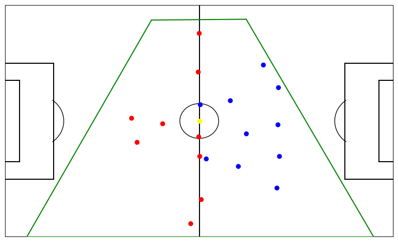

```python
def draw_event(event_id):
    # Create figure
    fig, ax = plt.subplots(figsize=(10, 6))  # Adjusted the aspect ratio

    # Set x and y axis limits
    plt.xlim(0, 120)
    plt.ylim(0, 80)

    # Pitch Outline & Centre Line
    plt.plot([0, 0], [0, 80], color="black")
    plt.plot([0, 120], [80, 80], color="black")
    plt.plot([120, 120], [80, 0], color="black")
    plt.plot([120, 0], [0, 0], color="black")
    plt.plot([60, 60], [0, 80], color="black")  # Changed center line to the middle

    # Left Penalty Area
    plt.plot([15, 15], [60, 20], color="black")
    plt.plot([0, 15], [60, 60], color="black")
    plt.plot([15, 0], [20, 20], color="black")

    # Right Penalty Area
    plt.plot([120, 105], [60, 60], color="black")
    plt.plot([105, 105], [60, 20], color="black")
    plt.plot([105, 120], [20, 20], color="black")

    # Left 6-yard Box
    plt.plot([0, 4.5], [54, 54], color="black")
    plt.plot([4.5, 4.5], [54, 26], color="black")
    plt.plot([4.5, 0], [26, 26], color="black")

    # Right 6-yard Box
    plt.plot([120, 115.5], [54, 54], color="black")
    plt.plot([115.5, 115.5], [54, 26], color="black")
    plt.plot([115.5, 120], [26, 26], color="black")

    # Prepare Circles; 10 yard circle at centre
    centreCircle = plt.Circle((60, 40), 6, color="black", fill=False)

    # Draw Circles
    ax.add_patch(centreCircle)

    # Prepare Arcs
    leftArc = patches.Arc((9, 40), height=18.3, width=18.3, angle=0, theta1=308, theta2=52, color="black")
    rightArc = patches.Arc((111, 40), height=18.3, width=18.3, angle=0, theta1=128, theta2=232, color="black")

    # Draw Arcs
    ax.add_patch(leftArc)
    ax.add_patch(rightArc)

    # Tidy Axes
    plt.axis('off')

    area = visible_area(event_id)

    for i in range(len(area) - 1):
        plt.plot([area.iloc[i].x, area.iloc[i+1].x], [area.iloc[i].y, area.iloc[i+1].y], color='green', zorder=5)






    positions = player_locations(event_id)

    for i in range(len(positions)):
        x = positions.iloc[i, 3]
        y = positions.iloc[i, 4]
        if positions.iloc[i, 0]:
            plt.scatter(x, y, color='yellow', zorder=5)
        elif positions.iloc[i, 1]:
            plt.scatter(x, y, color='red', zorder=5)
        elif positions.iloc[i, 2]:
            plt.scatter(x, y, color='green', zorder=5)
        else:
            plt.scatter(x, y, color='blue', zorder=5)


    plt.show()

# Draw the football pitch
draw_event('5d14bae0-f462-491c-9fc2-e55faec97743')
```

In the picture above, teammates are in red and opponents in blue. The green lines determines the area visible thanks to the broadcast camera. Below, the implementation of the Voronoi polygons to determine the dominance of each team on the field. This is a crucial step towards the PCM.

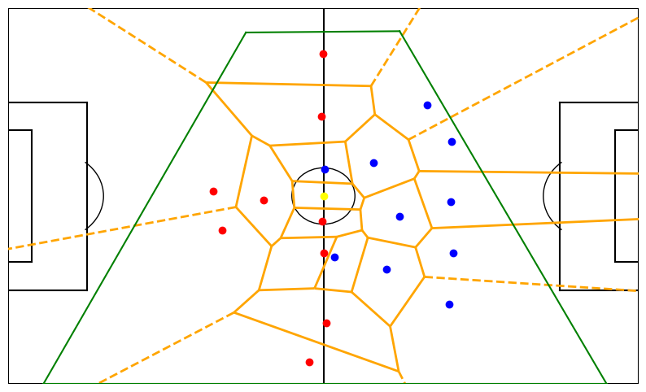

```python
def draw_event_voronoi(event_id):
    # Create figure
    fig, ax = plt.subplots(figsize=(10, 6))  # Adjusted the aspect ratio

    # Set x and y axis limits
    plt.xlim(0, 120)
    plt.ylim(0, 80)

    # Pitch Outline & Centre Line
    plt.plot([0, 0], [0, 80], color="black")
    plt.plot([0, 120], [80, 80], color="black")
    plt.plot([120, 120], [80, 0], color="black")
    plt.plot([120, 0], [0, 0], color="black")
    plt.plot([60, 60], [0, 80], color="black")  # Changed center line to the middle

    # Left Penalty Area
    plt.plot([15, 15], [60, 20], color="black")
    plt.plot([0, 15], [60, 60], color="black")
    plt.plot([15, 0], [20, 20], color="black")

    # Right Penalty Area
    plt.plot([120, 105], [60, 60], color="black")
    plt.plot([105, 105], [60, 20], color="black")
    plt.plot([105, 120], [20, 20], color="black")

    # Left 6-yard Box
    plt.plot([0, 4.5], [54, 54], color="black")
    plt.plot([4.5, 4.5], [54, 26], color="black")
    plt.plot([4.5, 0], [26, 26], color="black")

    # Right 6-yard Box
    plt.plot([120, 115.5], [54, 54], color="black")
    plt.plot([115.5, 115.5], [54, 26], color="black")
    plt.plot([115.5, 120], [26, 26], color="black")

    # Prepare Circles; 10 yard circle at centre
    centreCircle = plt.Circle((60, 40), 6, color="black", fill=False)

    # Draw Circles
    ax.add_patch(centreCircle)

    # Prepare Arcs
    leftArc = patches.Arc((9, 40), height=18.3, width=18.3, angle=0, theta1=308, theta2=52, color="black")
    rightArc = patches.Arc((111, 40), height=18.3, width=18.3, angle=0, theta1=128, theta2=232, color="black")

    # Draw Arcs
    ax.add_patch(leftArc)
    ax.add_patch(rightArc)

    # Tidy Axes
    plt.axis('off')

    area = visible_area(event_id)

    for i in range(len(area) - 1):
        plt.plot([area.iloc[i].x, area.iloc[i+1].x], [area.iloc[i].y, area.iloc[i+1].y], color='green', zorder=5)



    positions = player_locations(event_id)

    for i in range(len(positions)):
        x = positions.iloc[i, 3]
        y = positions.iloc[i, 4]
        if positions.iloc[i, 0]:
            plt.scatter(x, y, color='yellow', zorder=5)
        elif positions.iloc[i, 1]:
            plt.scatter(x, y, color='red', zorder=5)
        elif positions.iloc[i, 2]:
            plt.scatter(x, y, color='green', zorder=5)
        else:
            plt.scatter(x, y, color='blue', zorder=5)

    vor = scipy.spatial.Voronoi(np.array(positions[['x','y']]))

    scipy.spatial.voronoi_plot_2d(vor, ax=ax, show_vertices=False, line_colors='orange', line_width=2)

    plt.xlim(0, 120)
    plt.ylim(0, 80)
    plt.show()

# Draw the football pitch
draw_event_voronoi('5d14bae0-f462-491c-9fc2-e55faec97743')
```

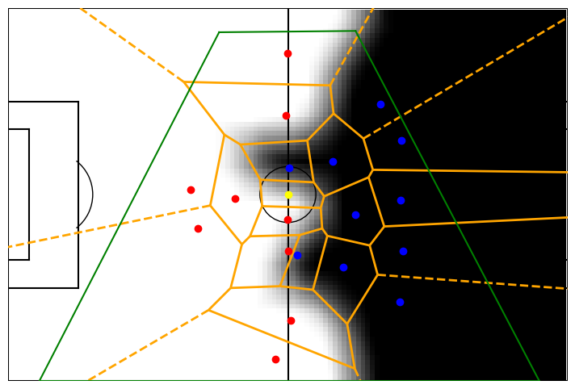

```python
def draw_event_voronoi_pcm(event_id):
    # Create figure
    fig, ax = plt.subplots(figsize=(10, 6))  # Adjusted the aspect ratio

    # Set x and y axis limits
    plt.xlim(0, 120)
    plt.ylim(0, 80)

    # Pitch Outline & Centre Line
    plt.plot([0, 0], [0, 80], color="black")
    plt.plot([0, 120], [80, 80], color="black")
    plt.plot([120, 120], [80, 0], color="black")
    plt.plot([120, 0], [0, 0], color="black")
    plt.plot([60, 60], [0, 80], color="black")  # Changed center line to the middle

    # Left Penalty Area
    plt.plot([15, 15], [60, 20], color="black")
    plt.plot([0, 15], [60, 60], color="black")
    plt.plot([15, 0], [20, 20], color="black")

    # Right Penalty Area
    plt.plot([120, 105], [60, 60], color="black")
    plt.plot([105, 105], [60, 20], color="black")
    plt.plot([105, 120], [20, 20], color="black")

    # Left 6-yard Box
    plt.plot([0, 4.5], [54, 54], color="black")
    plt.plot([4.5, 4.5], [54, 26], color="black")
    plt.plot([4.5, 0], [26, 26], color="black")

    # Right 6-yard Box
    plt.plot([120, 115.5], [54, 54], color="black")
    plt.plot([115.5, 115.5], [54, 26], color="black")
    plt.plot([115.5, 120], [26, 26], color="black")

    # Prepare Circles; 10 yard circle at centre
    centreCircle = plt.Circle((60, 40), 6, color="black", fill=False)

    # Draw Circles
    ax.add_patch(centreCircle)

    # Prepare Arcs
    leftArc = patches.Arc((9, 40), height=18.3, width=18.3, angle=0, theta1=308, theta2=52, color="black")
    rightArc = patches.Arc((111, 40), height=18.3, width=18.3, angle=0, theta1=128, theta2=232, color="black")

    # Draw Arcs
    ax.add_patch(leftArc)
    ax.add_patch(rightArc)

    # Tidy Axes
    plt.axis('off')

    area = visible_area(event_id)

    for i in range(len(area) - 1):
        plt.plot([area.iloc[i].x, area.iloc[i+1].x], [area.iloc[i].y, area.iloc[i+1].y], color='green', zorder=5)



    positions = player_locations(event_id)

    for i in range(len(positions)):
        x = positions.iloc[i, 3]
        y = positions.iloc[i, 4]
        if positions.iloc[i, 0]:
            plt.scatter(x, y, color='yellow', zorder=5)
        elif positions.iloc[i, 2]:
            plt.scatter(x, y, color='green', zorder=5)
        elif positions.iloc[i, 1]:
            plt.scatter(x, y, color='red', zorder=5)
        else:
            plt.scatter(x, y, color='blue', zorder=5)

    vor = scipy.spatial.Voronoi(np.array(positions[['x','y']]))

    scipy.spatial.voronoi_plot_2d(vor, ax=ax, show_vertices=False, line_colors='orange', line_width=2)
    plt.xlim(0, 120)
    plt.ylim(0, 80)

    voronoi_img = generate_voronoi_image(positions)
    plt.imshow(voronoi_img, cmap= 'gray')
    plt.axis('off')  # Turn off axis

    plt.show()

# Draw the football pitch
draw_event_voronoi_pcm('5d14bae0-f462-491c-9fc2-e55faec97743')
```

```python
def PC(event_id):
    positions = player_locations(event_id)
    voronoi_img = generate_voronoi_image(positions)

    return np.mean(voronoi_img)
```

```python
def PCM(event_id, player_location):
    positions = player_location
    voronoi_img = generate_voronoi_image(positions)
    #plt.imshow(voronoi_img, cmap='gray')
    #plt.axis('off')  # Turn off axis

    #plt.show()
    return voronoi_img.reshape(1,80,120)
```

```python
def states(event_id):
    pc_id = pc_series.loc[event_id].iloc[0]
    positions = player_locations(pc_id)
    actor_df = positions[positions['actor']]
    teammates_df = positions[positions['teammate']]
    opponents_df = positions[(~positions['teammate']) & (~positions['actor'])]

    # Function to plot points on an image
    def plot_points(df):
        img = np.zeros((80, 120), dtype=np.uint8)
        for index, row in df.iterrows():
            x, y = int(row['x']), int(row['y'])  # Ensure x and y are integers
            if y <= 80 and x <= 120:
                if y == 80 and x == 120:
                    img[y-1, x-1] = 1
                elif y == 80:
                    img[y-1, x] = 1
                elif x == 120:
                    img[y, x-1] = 1
                else:
                    img[y, x] = 1

        return img.reshape(1,80,120)


    # Plot images for actor, teammates, and opponents
    return np.concatenate([plot_points(actor_df), plot_points(teammates_df), plot_points(opponents_df), PCM(event_id, positions)])
```

We create the states for our dataset.

```python
pc_series = df_actions_C[['original_event_id', 'pc_id']].set_index('original_event_id')

state_EURO2020_C = np.empty((len(df_actions_C),4,80,120))

for i in range(len(state_EURO2020_C)):
    state_EURO2020_C[i] = states(df_actions_C.iloc[i,1])

state_EURO2020_C
```

# Action

We proceed with the creation of the action vector. Starting from df_actions, for each event, a one-hot encoding is applied on the type of action. Moreover, end_x and end_y are extracted. These describe the position on the pitch where the ball ends up at the end of the action. For the action vector, the dimensions of the football field are normalised, having the centre in (0,0) and the angles in (1,1), (-1,-1), (1,-1) and (-1,1).

```python
actions_vector = pd.concat([df_actions_C.original_event_id, pd.get_dummies(df_actions_C.type_name, dtype='int'), df_actions_C.end_x/105*2-1, df_actions_C.end_y/68*2-1], axis = 1).set_index('original_event_id')
action_EURO2020_C = np.array(actions_vector)
action_EURO2020_C
```

```
array([[ 0.        ,  0.        ,  0.        , ...,  0.        ,
        -0.3275    , -0.06625   ],
       [ 0.        ,  0.        ,  1.        , ...,  0.        ,
        -0.34583333, -0.07375   ],
       [ 0.        ,  0.        ,  0.        , ...,  0.        ,
        -0.2625    ,  0.20375   ],
       ...,
       [ 0.        ,  0.        ,  1.        , ...,  0.        ,
         0.42916667, -0.64875   ],
       [ 0.        ,  1.        ,  0.        , ...,  0.        ,
         0.84416667, -0.03125   ],
       [ 1.        ,  0.        ,  0.        , ...,  0.        ,
        -0.84416667,  0.03125   ]])
```

```python
actions_vector
```

[output not shown]

### An example of states and actions

[figure not shown]

[figure not shown]

[figure not shown]

# Terminal Flag

An episode is a concatenation of actions in a football match and it ends when the team in possesion of the ball at the start of the episode loses possesion. Thus, a terminal flag will be raised for any row if, and only if, the ball is turned over to the other football team. Observing the result_name column in df_actions, we can know if a team loses possesion after a specific action. For example, if a pass has failed then we can say that the ball has been turned over to the other side. By assumption, clearences and shots are always terminal states. Dribbles, are considered terminal only if the subsequent action in df_action is made by the other team, implying that an action that we have not considered in our "filtered" dataset of actions, has lead to a loss of possesion.

```python
df_actions_C['terminal_flag'] = 0
for i in range(len(df_actions_C)):
    if (df_actions_C.iloc[i].result_name == 'fail') | (df_actions_C.iloc[i].type_name == 'clearance') | (df_actions_C.iloc[i].type_name == 'shot'):
        df_actions_C.iloc[i,-1] = 1
    if i+1 != len(df_actions_C):
        if df_actions_C.iloc[i,4] != df_actions_C.iloc[i+1,4]:
            df_actions_C.iloc[i,-1] = 1
flag_EURO2020_C = np.array(df_actions_C.terminal_flag)
```

# Reward

Given the previously computed states and action vectors, we can now calculate the reward for all the events.

First, the reward for the shots will rely on df_event, where it is possible to access the Expected Goal (xG) for each shot. The xG value was computed by StatsBomb as a metric for evaluating how likely it is that the shot taken will result in a goal, given the state of the shot taker. Therefore, it is appropriate to consider xG as the reward that one recieves when they attempt a shot, given their position on the field.

```python
shots_in_action_df = df_actions_C[df_actions_C["type_name"]=="shot"]
shots_in_big_df = df_event[df_event["type_name"]=="Shot"]
shots_in_action_df['xG'] = 0

for i in range(len(shots_in_action_df)):
    id_of_shot=shots_in_action_df.iloc[i]["original_event_id"]
    row_in_df_with_shot_id=shots_in_big_df[shots_in_big_df["event_id"]==id_of_shot]
    extra=row_in_df_with_shot_id["extra"]
    xG=extra.iloc[0]["shot"]["statsbomb_xg"]
    #shots_in_action_df_copy.iloc[i]["reward"]=xG
    shots_in_action_df.iat[i,-1]=xG

xGoals = shots_in_action_df.iloc[:, [1,-1]].set_index('original_event_id')
xGoals
```

| original_event_id | xG |
| --- | --- |
| 7381ef62-f52c-4000-988a-e9bc5984343e | 0.023307 |
| 93a20467-069f-4f3b-961b-d6b013cd4a67 | 0.036135 |
| 3e4da094-fa68-4bc7-b693-2c0bf85ecc9f | 0.054447 |
| 0dda168f-fb80-432f-b371-fb542b25d4ae | 0.023486 |
| cc9ec3e3-beba-4c02-932f-3abf45b9834e | 0.298781 |
| ... | ... |
| 9a85333d-1e61-4e2f-8ae6-b079d43231af | 0.010371 |
| 7998e42d-5e89-4a99-9555-74c403a460ba | 0.037296 |
| 63ea61d8-870e-427a-8bf8-40881ad17884 | 0.059264 |
| 8c998ca1-ac73-4def-acee-bca4c9f48809 | 0.050867 |
| de99a149-f96f-4b7f-a783-cdc08f7fbc42 | 0.031470 |

139 rows × 1 columns

Now, we focus on the computation of the reward for all the events whose action type is one where the ball gets progressed (in other words, an action in the set [pass, dribble, cross]). The reward will depend on 2 factors: how likely it is that the destination of the action leads to a goal and how likely is it that the the action leads to loss of possesion.

As in Pulis (2023), we argue that this is a valid method for scoring ball progressing actions because the football team in possesion only cares about 2 things: scoring goals to win the match and maintaining possesion to prevent conceding goals. In opposition to Pulis (2023) where On-Ball Value (OBV) is used, in order to measure how likely it is that an action leads to a goal we utilise the Expected Threat (xT). The theoretical model was developed by Singh (2018) and has the following formula:

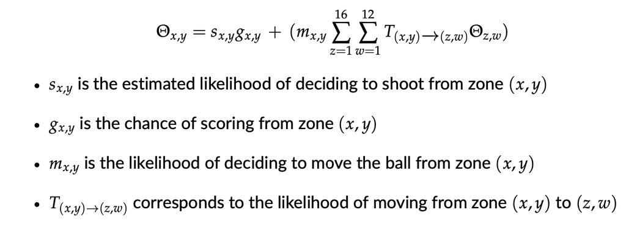

The formula above describes the xT of a pass that it is made from (x, y) to (z,w). After calling the xT model, we apply it on df_actions. The xT model automatically applies solely on actions that are ball progressing, such that a resultant dataframe called df_mov_actions is created which will contain the xT values in its xT_value column.

```python
# 3. Train xT model with 16 x 12 grid
xTModel = xthreat.ExpectedThreat(l=16, w=12)
xTModel.fit(df_actions_C)

# 4. Rate ball-progressing actions
# xT should only be used to value actions that move the ball
# and that keep the current team in possession of the ball
df_mov_actions = xthreat.get_successful_move_actions(df_actions_C)
df_mov_actions["xT_value"] = xTModel.rate(df_mov_actions)
xThreat = df_mov_actions[['original_event_id', 'xT_value']].set_index('original_event_id')
xThreat
```

```
# iterations:  45
```

```python
df_mov_actions
```

[output not shown]

325571 rows × 20 columns

```python
xThreat
```

| original_event_id | xT_value |
| --- | --- |
| 75d6cc25-b03b-44e0-9c50-99a7e3c47315 | 0.000000 |
| 246b93aa-3831-4b07-a51e-b6ba578e60d5 | -0.002207 |
| e8a3f021-76da-443b-9a1d-c5857c486493 | 0.000000 |
| a866dfc1-a61a-4a46-bd83-86e8de9c0d69 | -0.001562 |
| a09b819b-6bfc-4870-99ce-148c630724a8 | 0.000547 |
| ... | ... |
| d5fbdc50-85bc-42c9-835e-001b5fbddbd1 | 0.002921 |
| c1482b1b-603d-455d-8940-7f0c6e2eee2a | 0.000000 |
| f73fe4fb-44cd-41d1-b25f-72fedcf709d7 | 0.001860 |
| 17b03ad4-46f2-4e0f-bef4-bb693a041755 | -0.001864 |
| 514cd909-d1b6-4c74-990e-c3d580d07354 | 0.000000 |

325571 rows × 1 columns

As far as the second factor influencing ball-progressing actions, that is the likelihood that the action leads to possesion loss, we use the mean of the PCM array (i.e. the fourth array in our states) to come up with our desired score. In particular, a mean value close to 1 will mean that the team in possession of the ball has significant dominance on the field, otherwise the mean PCM value will be closer to 0.

Below, the definition of our reward function which takes as input an event from a football match and returns as output its corresponding reward. In particular, we associate the already discussed rewards to the corresponding acrions. For clearences, we set as reward a tiny positive epsilon. This is due to the fact that usually defenders clear the ball only if the situation in which they find themselves is such critical that even losing the possesion further away than in the zone where the action is happening is lowering the chances of scoring of the other team. For this reason, in accordance to Pulis (2023), we do not penalise clearences. All other losing-possession actions are penalised giving -1 as reward.

```python
def reward(event_id):
    row = df_actions_index.loc[event_id]
    action = row.type_name
    flag = row.terminal_flag

    if action == 'pass' or action == 'dribble' or action == 'cross':
        if flag == 1:
            return -1
        elif flag == 0 and event_id in xThreat.index:
            xT = float(xThreat.loc[event_id].iloc[0])
            return xT * PC(row.pc_id) if xT > 0 else xT * (1 - PC(row.pc_id))
        else:
            return 0
    elif action == 'shot':
        return float(xGoals.loc[event_id].iloc[0])
    else:
        return 1e-3
```

```python
df_event_id = df_event[['freeze_frame_360', 'event_id']].set_index('event_id')
df_actions_index = df_actions_C.set_index('original_event_id', drop=True)
```

```python
reward_EURO2020_C = np.empty(len(df_actions_C))

for i in range(len(reward_EURO2020_C)):
    reward_EURO2020_C[i] = reward(df_actions_C.iloc[i,1])
```

At this point, we have created the RL data set corresponding to the matches in Group C of EURO 2020, since for each event we have the state, action, reward and terminal_flag. Now, we proceed to do the same, but for Group A of EURO 2020.

### Generating State, Action, Reward, Terminal for group A

```python
df_actions_A = df_actions[df_actions.game_id.isin(list(group_A.game_id.astype(str)))]
actions_vector = pd.concat([df_actions_A.original_event_id, pd.get_dummies(df_actions_A.type_name, dtype='int'), df_actions_A.end_x/105*2-1, df_actions_A.end_y/68*2-1], axis = 1).set_index('original_event_id')
```

```python
df_actions_A['terminal_flag'] = 0
for i in range(len(df_actions_A)):
    if (df_actions_A.iloc[i].result_name == 'fail') | (df_actions_A.iloc[i].type_name == 'clearance') | (df_actions_A.iloc[i].type_name == 'shot'):
        df_actions_A.iloc[i,-1] = 1
    if i+1 != len(df_actions_A):
        if df_actions_A.iloc[i,4] != df_actions_A.iloc[i+1,4]:
            df_actions_A.iloc[i,-1] = 1


# 3. Train xT model with 16 x 12 grid
xTModel = xthreat.ExpectedThreat(l=16, w=12)
xTModel.fit(df_actions_A)

# 4. Rate ball-progressing actions
# xT should only be used to value actions that move the ball
# and that keep the current team in possession of the ball
df_mov_actions = xthreat.get_successful_move_actions(df_actions_A)
df_mov_actions["xT_value"] = xTModel.rate(df_mov_actions)

xThreat = df_mov_actions[['original_event_id', 'xT_value']].set_index('original_event_id')

shots_in_action_df = df_actions_A[df_actions_A["type_name"]=="shot"]
shots_in_big_df = df_event[df_event["type_name"]=="Shot"]
shots_in_action_df['xG'] = 0

for i in range(len(shots_in_action_df)):
    id_of_shot=shots_in_action_df.iloc[i]["original_event_id"]
    row_in_df_with_shot_id=shots_in_big_df[shots_in_big_df["event_id"]==id_of_shot]
    extra=row_in_df_with_shot_id["extra"]
    xG=extra.iloc[0]["shot"]["statsbomb_xg"]
    #shots_in_action_df_copy.iloc[i]["reward"]=xG
    shots_in_action_df.iat[i,-1]=xG

xGoals = shots_in_action_df.iloc[:, [1,-1]].set_index('original_event_id')

flag_EURO2020_A = np.array(df_actions_A.terminal_flag)

action_EURO2020_A = np.array(actions_vector)

df_event_id = df_event[['freeze_frame_360', 'event_id']].set_index('event_id')
df_actions_index = df_actions_A.set_index('original_event_id', drop=True)
reward_EURO2020_A = np.empty(len(df_actions_A))

for i in range(len(reward_EURO2020_A)):
    reward_EURO2020_A[i] = reward(df_actions_A.iloc[i,1])

pc_series = df_actions_A[['original_event_id', 'pc_id']].set_index('original_event_id')
state_EURO2020_A = np.empty((len(df_actions_A),4,80,120))

for i in range(len(state_EURO2020_A)):
    state_EURO2020_A[i] = states(df_actions_A.iloc[i,1])
```

### 3.3 Models implementation

We will rely on deep RL as the method for generating our desired model.

In particular, we will choose an algorithm which falls under the policy gradient class. They were introduced by Williams [16] and they attempt to address model contexts where the actions space is continous. Thus, it is reasonable to choose a policy gradient method as our action space has continous values for its last two values, which describe the position on the pitch where the ball ends up after the completion of the action. Moreover, we will employ the actor-crtic technique as this offers variance reduction properties, while still being an example of a policy gradient method.

At the same time, the model we choose needs to be made for offline-learning as we are working with a dataset that has already been generated (static dataset). Two algorithms which fit all of these criterions are: Advantage-Weighted Actor-Critic (AWAC) and Implicit Q-Learning (IQL). AWAC was introduced by Nair et al. [17] and IQL was introduced by Kostrikov et al. [18]. IQL's main contribution relies in the fact that it attempts to mitigate the problem of how the critic might evluate state action pairs which are not visited. This would be very helpful for our project, as the state-action space in our dataset is large and, at the same time, we are not using a huge dataset.

```python
import d3rlpy

EURO2020_A = d3rlpy.dataset.MDPDataset(
    observations=state_EURO2020_A,
    actions=action_EURO2020_A,
    rewards=reward_EURO2020_A,
    terminals=flag_EURO2020_A,
)

EURO2020_C = d3rlpy.dataset.MDPDataset(
    observations=state_EURO2020_C,
    actions=action_EURO2020_C,
    rewards=reward_EURO2020_C,
    terminals=flag_EURO2020_C,
)
```

### 3.3.1 AWAC

[AWAC](https://d3rlpy.readthedocs.io/en/v2.2.0/references/algos.html#awac) (Advantage Weighted Actor-Critic algorithm) is a TD3-based actor-critic algorithm that enables efficient fine-tuning where the policy is trained with offline datasets.

The policy is trained as a supervised regression.

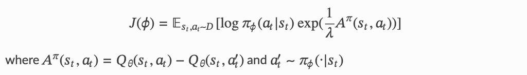

```python
awac = d3rlpy.algos.AWACConfig(critic_learning_rate=1.5e-5, actor_learning_rate=9.7e-8).create('cuda')

history = awac.fit(EURO2020_A, n_steps=10000, n_steps_per_epoch=1000)

awac.save_model('awac_euro.pt')
```

```
2024-05-14 19:38.04 [info     ] dataset info                   dataset_info=DatasetInfo(observation_signature=Signature(dtype=[dtype('float64')], shape=[(4, 80, 120)]), action_signature=Signature(dtype=[dtype('float64')], shape=[(7,)]), reward_signature=Signature(dtype=[dtype('float64')], shape=[(1,…
2024-05-14 19:38.04 [info     ] Directory is created at d3rlpy_logs/AWAC_20240514193804
2024-05-14 19:38.04 [debug    ] Building models...
2024-05-14 19:38.05 [debug    ] Models have been built.
2024-05-14 19:38.05 [info     ] Parameters                     params={'observation_shape': [4, 80, 120], 'action_size': 7, 'config': {'type': 'awac', 'params': {'batch_size': 1024, 'gamma': 0.99, 'observation_scaler': {'type': 'none', 'params': {}}, 'action_scaler': {'type': 'none', 'params': {}}, …
```

```
2024-05-14 19:48.35 [info     ] AWAC_20240514193804: epoch=1 step=1000 epoch=1 metrics={'time_sample_batch': 0.38951533222198487, 'time_algorithm_update': 0.23840443301200867, 'critic_loss': 124.36732118606568, 'actor_loss': 295831.65965625, 'temp': 0.0, 'temp_loss': 0.0, 'time_step': 0.628095452308…
2024-05-14 19:48.35 [info     ] Model parameters are saved to d3rlpy_logs/AWAC_20240514193804/model_1000.d3
```

```
2024-05-14 19:58.47 [info     ] AWAC_20240514193804: epoch=2 step=2000 epoch=2 metrics={'time_sample_batch': 0.37380899167060855, 'time_algorithm_update': 0.23651389408111573, 'critic_loss': 473.5523515472412, 'actor_loss': 281541.7546875, 'temp': 0.0, 'temp_loss': 0.0, 'time_step': 0.61050082612037…
2024-05-14 19:58.47 [info     ] Model parameters are saved to d3rlpy_logs/AWAC_20240514193804/model_2000.d3
```

```
2024-05-14 20:08.57 [info     ] AWAC_20240514193804: epoch=3 step=3000 epoch=3 metrics={'time_sample_batch': 0.37139919519424436, 'time_algorithm_update': 0.23681229948997498, 'critic_loss': 880.019583190918, 'actor_loss': 265078.002734375, 'temp': 0.0, 'temp_loss': 0.0, 'time_step': 0.6083859260082…
2024-05-14 20:08.58 [info     ] Model parameters are saved to d3rlpy_logs/AWAC_20240514193804/model_3000.d3
```

```
2024-05-14 20:19.05 [info     ] AWAC_20240514193804: epoch=4 step=4000 epoch=4 metrics={'time_sample_batch': 0.3690995051860809, 'time_algorithm_update': 0.2363374536037445, 'critic_loss': 1181.8154282836915, 'actor_loss': 249609.322953125, 'temp': 0.0, 'temp_loss': 0.0, 'time_step': 0.6056071929931…
2024-05-14 20:19.05 [info     ] Model parameters are saved to d3rlpy_logs/AWAC_20240514193804/model_4000.d3
```

```
2024-05-14 20:29.14 [info     ] AWAC_20240514193804: epoch=5 step=5000 epoch=5 metrics={'time_sample_batch': 0.3707629828453064, 'time_algorithm_update': 0.2368553240299225, 'critic_loss': 1388.066316772461, 'actor_loss': 236774.01, 'temp': 0.0, 'temp_loss': 0.0, 'time_step': 0.6077756764888763} ste…
2024-05-14 20:29.14 [info     ] Model parameters are saved to d3rlpy_logs/AWAC_20240514193804/model_5000.d3
```

```
2024-05-14 20:39.18 [info     ] AWAC_20240514193804: epoch=6 step=6000 epoch=6 metrics={'time_sample_batch': 0.3659134078025818, 'time_algorithm_update': 0.23580541825294496, 'critic_loss': 1511.3767807617187, 'actor_loss': 227646.259203125, 'temp': 0.0, 'temp_loss': 0.0, 'time_step': 0.601857009649…
2024-05-14 20:39.18 [info     ] Model parameters are saved to d3rlpy_logs/AWAC_20240514193804/model_6000.d3
```

```
2024-05-14 20:49.27 [info     ] AWAC_20240514193804: epoch=7 step=7000 epoch=7 metrics={'time_sample_batch': 0.37181849336624145, 'time_algorithm_update': 0.23573000979423522, 'critic_loss': 1581.2732109375, 'actor_loss': 222198.782796875, 'temp': 0.0, 'temp_loss': 0.0, 'time_step': 0.60769572162628…
2024-05-14 20:49.28 [info     ] Model parameters are saved to d3rlpy_logs/AWAC_20240514193804/model_7000.d3
```

```
2024-05-14 20:59.34 [info     ] AWAC_20240514193804: epoch=8 step=8000 epoch=8 metrics={'time_sample_batch': 0.3695802376270294, 'time_algorithm_update': 0.23578474187850954, 'critic_loss': 1596.1060805664063, 'actor_loss': 219757.609140625, 'temp': 0.0, 'temp_loss': 0.0, 'time_step': 0.605523938417…
2024-05-14 20:59.35 [info     ] Model parameters are saved to d3rlpy_logs/AWAC_20240514193804/model_8000.d3
```

```
2024-05-14 21:09.38 [info     ] AWAC_20240514193804: epoch=9 step=9000 epoch=9 metrics={'time_sample_batch': 0.3655612773895264, 'time_algorithm_update': 0.23603284978866576, 'critic_loss': 1560.4142137451172, 'actor_loss': 220302.91209375, 'temp': 0.0, 'temp_loss': 0.0, 'time_step': 0.6017710435390…
2024-05-14 21:09.38 [info     ] Model parameters are saved to d3rlpy_logs/AWAC_20240514193804/model_9000.d3
```

```
2024-05-14 21:19.42 [info     ] AWAC_20240514193804: epoch=10 step=10000 epoch=10 metrics={'time_sample_batch': 0.36567599201202394, 'time_algorithm_update': 0.23602359795570374, 'critic_loss': 1481.8846710205078, 'actor_loss': 221157.875328125, 'temp': 0.0, 'temp_loss': 0.0, 'time_step': 0.60185559…
2024-05-14 21:19.42 [info     ] Model parameters are saved to d3rlpy_logs/AWAC_20240514193804/model_10000.d3
```

```python
 actor, critic = [], []
for i in range(len(history)):
  actor.append((history[i][1]['actor_loss']))
  critic.append((history[i][1]['critic_loss']))
```

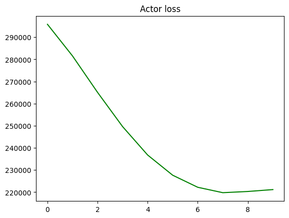

```python
plt.plot(actor, color = 'green')
plt.title('Actor loss')
```

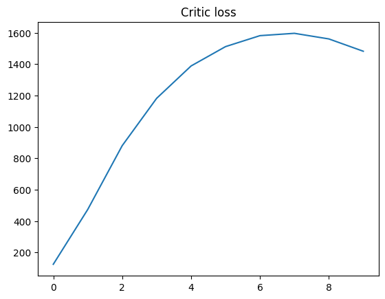

```python
plt.plot(critic)
plt.title('Critic loss')
```

```python
awac = d3rlpy.algos.AWACCOnfig(actor_learning_rate = 3.4e-7, critic_learning_rate = 9.8e-8).create(device="cpu")

# initialize with dataset
awac.build_with_dataset(EURO2020_A)

# load entire model parameters.
awac.load_model(folder+'awac_euro.pt')
```

### 3.3.2 IQL

[IQL](https://d3rlpy.readthedocs.io/en/v2.2.0/references/algos.html#iql) (Implicit Q-Learning algorithm) is the offline RL algorithm that avoids ever querying values of unseen actions while still being able to perform multi-step dynamic programming updates.

There are three functions to train in IQL. First the state-value function is trained via expectile regression.

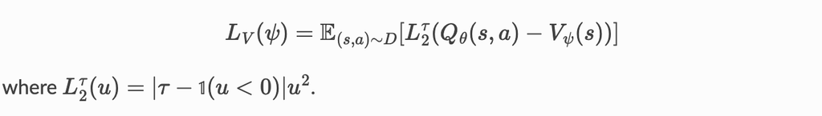

The Q-function is trained with the state-value function to avoid query the actions.

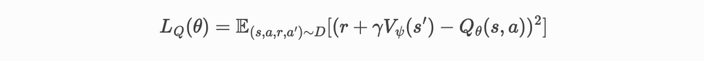

Finally, the policy function is trained by using advantage weighted regression.

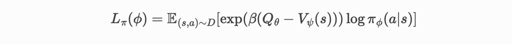

```python
iql = d3rlpy.algos.IQLConfig(actor_learning_rate = 3.4e-7, critic_learning_rate = 9.8e-8).create(device="cuda")

history = iql.fit(EURO2020_A, n_steps=10000,n_steps_per_epoch=1000,
                  evaluators={
        'td_error': d3rlpy.metrics.TDErrorEvaluator(EURO2020_C.episodes)}
                  )
```

```
2024-05-14 17:13.27 [info     ] dataset info                   dataset_info=DatasetInfo(observation_signature=Signature(dtype=[dtype('float64')], shape=[(4, 80, 120)]), action_signature=Signature(dtype=[dtype('float64')], shape=[(7,)]), reward_signature=Signature(dtype=[dtype('float64')], shape=[(1,…
2024-05-14 17:13.27 [info     ] Directory is created at d3rlpy_logs/IQL_20240514171327
2024-05-14 17:13.27 [debug    ] Building models...
2024-05-14 17:13.28 [debug    ] Models have been built.
2024-05-14 17:13.28 [info     ] Parameters                     params={'observation_shape': [4, 80, 120], 'action_size': 7, 'config': {'type': 'iql', 'params': {'batch_size': 256, 'gamma': 0.99, 'observation_scaler': {'type': 'none', 'params': {}}, 'action_scaler': {'type': 'none', 'params': {}}, 'r…
```

```
2024-05-14 17:16.39 [info     ] IQL_20240514171327: epoch=1 step=1000 epoch=1 metrics={'time_sample_batch': 0.10487311363220214, 'time_algorithm_update': 0.07374990344047547, 'critic_loss': 0.1773652146756649, 'q_loss': 0.177304597184062, 'v_loss': 6.061727223641355e-05, 'actor_loss': 9.833179808139…
2024-05-14 17:16.40 [info     ] Model parameters are saved to d3rlpy_logs/IQL_20240514171327/model_1000.d3
```

```
2024-05-14 17:19.59 [info     ] IQL_20240514171327: epoch=2 step=2000 epoch=2 metrics={'time_sample_batch': 0.1093151617050171, 'time_algorithm_update': 0.07595821070671081, 'critic_loss': 0.15751133611798288, 'q_loss': 0.15745644120126961, 'v_loss': 5.489473920533783e-05, 'actor_loss': 7.2929458799…
2024-05-14 17:19.59 [info     ] Model parameters are saved to d3rlpy_logs/IQL_20240514171327/model_2000.d3
```

```
2024-05-14 17:23.18 [info     ] IQL_20240514171327: epoch=3 step=3000 epoch=3 metrics={'time_sample_batch': 0.10956359910964966, 'time_algorithm_update': 0.07509061574935913, 'critic_loss': 0.13459794383496046, 'q_loss': 0.13454567679017782, 'v_loss': 5.22670547470625e-05, 'actor_loss': 6.7746900682…
2024-05-14 17:23.18 [info     ] Model parameters are saved to d3rlpy_logs/IQL_20240514171327/model_3000.d3
```

```
2024-05-14 17:26.21 [info     ] IQL_20240514171327: epoch=4 step=4000 epoch=4 metrics={'time_sample_batch': 0.10076858329772949, 'time_algorithm_update': 0.06897480249404907, 'critic_loss': 0.11917315286397934, 'q_loss': 0.1191219632178545, 'v_loss': 5.118972637501429e-05, 'actor_loss': 6.6274554724…
2024-05-14 17:26.21 [info     ] Model parameters are saved to d3rlpy_logs/IQL_20240514171327/model_4000.d3
```

```
2024-05-14 17:29.24 [info     ] IQL_20240514171327: epoch=5 step=5000 epoch=5 metrics={'time_sample_batch': 0.10182745265960694, 'time_algorithm_update': 0.06876035308837891, 'critic_loss': 0.10410513457655907, 'q_loss': 0.10405607438459992, 'v_loss': 4.906017745815916e-05, 'actor_loss': 6.430922435…
2024-05-14 17:29.24 [info     ] Model parameters are saved to d3rlpy_logs/IQL_20240514171327/model_5000.d3
```

```
2024-05-14 17:32.28 [info     ] IQL_20240514171327: epoch=6 step=6000 epoch=6 metrics={'time_sample_batch': 0.10199976444244385, 'time_algorithm_update': 0.06956462526321411, 'critic_loss': 0.09502655469626188, 'q_loss': 0.09497983646020293, 'v_loss': 4.6718022236746037e-05, 'actor_loss': 6.21288582…
2024-05-14 17:32.28 [info     ] Model parameters are saved to d3rlpy_logs/IQL_20240514171327/model_6000.d3
```

```
2024-05-14 17:35.32 [info     ] IQL_20240514171327: epoch=7 step=7000 epoch=7 metrics={'time_sample_batch': 0.10158134317398071, 'time_algorithm_update': 0.06934159111976623, 'critic_loss': 0.08862951040267944, 'q_loss': 0.08858319577947259, 'v_loss': 4.6314695478940847e-05, 'actor_loss': 5.99121366…
2024-05-14 17:35.32 [info     ] Model parameters are saved to d3rlpy_logs/IQL_20240514171327/model_7000.d3
```

```
2024-05-14 17:38.35 [info     ] IQL_20240514171327: epoch=8 step=8000 epoch=8 metrics={'time_sample_batch': 0.10116106700897216, 'time_algorithm_update': 0.06919708824157715, 'critic_loss': 0.08299770826473832, 'q_loss': 0.08295193806290627, 'v_loss': 4.577017148767481e-05, 'actor_loss': 5.787173341…
2024-05-14 17:38.36 [info     ] Model parameters are saved to d3rlpy_logs/IQL_20240514171327/model_8000.d3
```

```
2024-05-14 17:41.37 [info     ] IQL_20240514171327: epoch=9 step=9000 epoch=9 metrics={'time_sample_batch': 0.1003543860912323, 'time_algorithm_update': 0.06896095752716064, 'critic_loss': 0.0785191536359489, 'q_loss': 0.07847335335984826, 'v_loss': 4.580030630677357e-05, 'actor_loss': 5.64809717845…
2024-05-14 17:41.38 [info     ] Model parameters are saved to d3rlpy_logs/IQL_20240514171327/model_9000.d3
```

```
2024-05-14 17:44.42 [info     ] IQL_20240514171327: epoch=10 step=10000 epoch=10 metrics={'time_sample_batch': 0.10165349459648132, 'time_algorithm_update': 0.07000854277610778, 'critic_loss': 0.07404202299192547, 'q_loss': 0.07399575327336788, 'v_loss': 4.626977295629331e-05, 'actor_loss': 5.536118…
2024-05-14 17:44.42 [info     ] Model parameters are saved to d3rlpy_logs/IQL_20240514171327/model_10000.d3
```

```python
td, actor, critic = [], [], []
for i in range(len(history)):
    td.append((history[i][1]['td_error']))
    actor.append((history[i][1]['actor_loss']))
    critic.append((history[i][1]['critic_loss']))
```

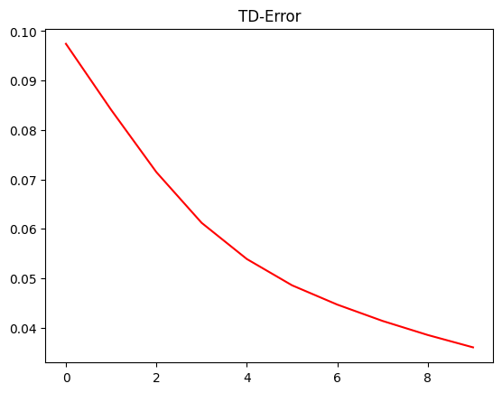

```python
plt.plot(td, color = 'red')
plt.title('TD-Error')
```

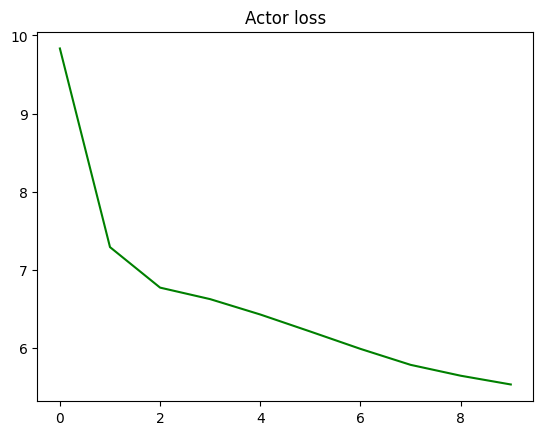

```python
plt.plot(actor, color = 'green')
plt.title('Actor loss')
```

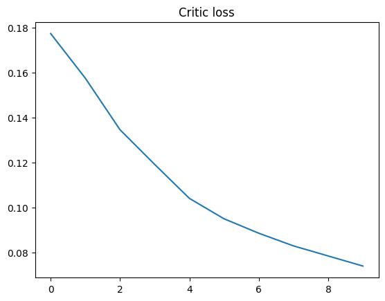

```python
plt.plot(critic)
plt.title('Critic loss')
```

```python
iql.save_model('iql_euro.pt')
```

```python
iql = d3rlpy.algos.IQLConfig(actor_learning_rate = 3.4e-7, critic_learning_rate = 9.8e-8).create(device="cpu")

# initialize with dataset
iql.build_with_dataset(EURO2020_A)

# load entire model parameters.
iql.load_model(folder+'iql_euro.pt')
```

#### Evaluation

The plots for AWAC show a clear indication of overfitting, whereas the plots for the IQL shows that both the actor and the critic are learning.

Based on this, we choose the model generated from the IQL algorithm. This is also in accordance to Pulis (2023).

## 4. Results

In the following section we are going to predict the decision value (DV) for specific sets of actions that will allow us to expand on the work of Pulis (2023) and to prove the validity of this method.

### 4.1 Preliminary results

#### 4.1.1 Group Stage Performance

First, we predict the DVs for the test set, which contains all the episodes of the matches for group C.

```python
pred = iql.predict_value(action = action_EURO2020_C, x = state_EURO2020_C)
```

The DV of an action represents the effect of that action on the expected return, given a state.

This value is very useful as it offers us a metric for comparing different actions.

```python
pd.DataFrame(pred)
```

|  | 0 |
| --- | --- |
| 0 | -0.570025 |
| 1 | -0.574310 |
| 2 | -0.576043 |
| 3 | -0.554358 |
| 4 | -0.567448 |
| ... | ... |
| 11227 | -0.638382 |
| 11228 | -0.644850 |
| 11229 | -0.635766 |
| 11230 | -0.638295 |
| 11231 | -0.646550 |

11232 rows × 1 columns

For each action of the test set, we create a dataframe (obs_game) that associates the game_id the name of the teams and the name of the players performing the various actions.

```python
obs_game = pd.DataFrame(columns = ['game_id', 'team_name', 'player_name'])
for i in range(len(df_actions_C)):
    match_id = int(df_actions_C.iloc[i].game_id)
    teams = api.teams(match_id).set_index('team_id', drop = True)
    players = api.players(match_id).set_index('player_id', drop = True)
    obs_game.loc[len(obs_game)] = match_id, teams.loc[df_actions_C.iloc[i].team_id].values[0], players.loc[df_actions_C.iloc[i].player_id].iloc[2]

obs_game
```

```python
obs_game
```

|  | game_id | team_name | player_name |
| --- | --- | --- | --- |
| 0 | 3788758 | North Macedonia | Goran Pandev |
| 1 | 3788758 | North Macedonia | Darko Velkovski |
| 2 | 3788758 | North Macedonia | Darko Velkovski |
| 3 | 3788758 | North Macedonia | Enis Bardhi |
| 4 | 3788758 | North Macedonia | Enis Bardhi |
| ... | ... | ... | ... |
| 11227 | 3788756 | Austria | Florian Grillitsch |
| 11228 | 3788756 | Austria | Florian Grillitsch |
| 11229 | 3788756 | Austria | Philipp Lienhart |
| 11230 | 3788756 | Austria | Philipp Lienhart |
| 11231 | 3788756 | Netherlands | Stefan de Vrij |

11232 rows × 3 columns

Following, we compute the mean DV for each team.

```python
np.mean(pred[obs_game.team_name == 'North Macedonia'])
```

```
-0.5674352
```

```python
np.mean(pred[obs_game.team_name == 'Austria'])
```

```
-0.5820339
```

```python
np.mean(pred[obs_game.team_name == 'Netherlands'])
```

```
-0.5829807
```

```python
np.mean(pred[obs_game.team_name == 'Ukraine'])
```

```
-0.57995325
```

The predictions of our model on all the events of the group stage makes us to make the following ranking among the teams in group C:

1. North Macedonia
2. Ukraine
3. Austria
4. Netherlands

The above ranking, however, is in complete opposition of the actual outcome of the UEFA Euro 2020 Group C, that was:

1. Netherlands
2. Austria
3. Ukraine
4. North Macedonia

We observe that the mean DVs are not very different in magnitude, reflecting a minimal difference in the performances of the players of each team throughout the games of the group stage. For this reason, we believe that the 6 matches given to the model for training were not enough to highlight real differences across the teams and to predict a realistic difference in DVs that would reflect what happened in reality.

#### 4.1.2 Single match performance

## North Macedonia - Ukraine 1-2

```python
np.mean(pred[(obs_game.game_id == 3788758) & (obs_game.team_name == 'North Macedonia')])
```

```
-0.5679513
```

```python
np.mean(pred[(obs_game.game_id == 3788758) & (obs_game.team_name == 'Ukraine')])
```

```
-0.5874468
```

The prediction does not align with the outcome of the match.

## Austria - Netherlands 0-2

```python
np.mean(pred[(obs_game.game_id == 3788756) & (obs_game.team_name == 'Austria')])
```

```
-0.57583106
```

```python
np.mean(pred[(obs_game.game_id == 3788756) & (obs_game.team_name == 'Netherlands')])
```

```
-0.57235706
```

The prediction aligns with the outcome of the match.

## North Macedonia - Netherlands 0-3

```python
np.mean(pred[(obs_game.game_id == 3788770) & (obs_game.team_name == 'North Macedonia')])
```

```
-0.56628287
```

```python
np.mean(pred[(obs_game.game_id == 3788770) & (obs_game.team_name == 'Netherlands')])
```

```
-0.5845524
```

The prediction does not align with the outcome of the match.

## North Macedonia - Austria 1-3

```python
np.mean(pred[(obs_game.game_id == 3788747) & (obs_game.team_name == 'North Macedonia')])
```

```
-0.5682646
```

```python
np.mean(pred[(obs_game.game_id == 3788747) & (obs_game.team_name == 'Austria')])
```

```
-0.59155166
```

The prediction does not align with the outcome of the match.

## Ukraine - Austria 0-1

```python
np.mean(pred[(obs_game.game_id == 3788767) & (obs_game.team_name == 'Ukraine')])
```

```
-0.5846751
```

```python
np.mean(pred[(obs_game.game_id == 3788767) & (obs_game.team_name == 'Austria')])
```

```
-0.57747924
```

The prediction aligns with the outcome of the match.

## Ukraine - Netherlands 2-3

```python
np.mean(pred[(obs_game.game_id == 3788746) & (obs_game.team_name == 'Ukraine')])
```

```
-0.56567055
```

```python
np.mean(pred[(obs_game.game_id == 3788746) & (obs_game.team_name == 'Netherlands')])
```

```
-0.5886952
```

The prediction does not align with the outcome of the match.

### 4.2 MVP Analysis

We create a function to calculate the best players, in terms of mean DVs, for each match. In particular, we select to compute the mean DV only for the players that participated as actors to at least 20 events.

```python
def mvp(match_id):
    match_obs = obs_game[obs_game.game_id == match_id]
    out = pd.DataFrame(columns = ['player', 'mean_dv'])
    for player in match_obs.player_name.unique():
        if len(pred[(obs_game.game_id == match_id) & (obs_game.player_name == player)]) > 20:
            out.loc[len(out)] = player, np.mean(pred[(obs_game.game_id == match_id) & (obs_game.player_name == player)])
    return out.sort_values('mean_dv', ascending = False).reset_index(drop=True)
```

## North Macedonia - Ukraine

```python
mvp(3788758)
```

|  | player | mean_dv |
| --- | --- | --- |
| 0 | Stole Dimitrievski | -0.528602 |
| 1 | Aleksandar Trajkovski | -0.549947 |
| 2 | Stefan Ristovski | -0.557639 |
| 3 | Boban Nikolov | -0.558457 |
| 4 | Enis Bardhi | -0.560108 |
| 5 | Heorhii Bushchan | -0.560762 |
| 6 | Ezgjan Alioski | -0.560945 |
| 7 | Eljif Elmas | -0.564422 |
| 8 | Stefan Spirovski | -0.565417 |
| 9 | Ruslan Malinovskiy | -0.568120 |
| 10 | Andriy Yarmolenko | -0.572766 |
| 11 | Roman Yaremchuk | -0.576117 |
| 12 | Oleksandr Karavaev | -0.579409 |
| 13 | Goran Pandev | -0.580941 |
| 14 | Darko Velkovski | -0.581212 |
| 15 | Viktor Tsygankov | -0.581501 |
| 16 | Visar Musliu | -0.582001 |
| 17 | Arijan Ademi | -0.587207 |
| 18 | Mykola Matviyenko | -0.591267 |
| 19 | Oleksandr Zinchenko | -0.594468 |
| 20 | Mykola Shaparenko | -0.595314 |
| 21 | Taras Stepanenko | -0.595370 |
| 22 | Vitalii Mykolenko | -0.599273 |
| 23 | Illia Zabarnyi | -0.606104 |

The [Sofascore match analysis](https://www.sofascore.com/north-macedonia-ukraine/bUbsCVb#id:8602446) reveals Dimitrievski as the MVP and top performer with the best mean DV, with Trajkovski closely following as the second-best player and a standout for North Macedonia. However, our predictions for Yarmolenko and Malinovskyi were less accurate, as they ranked 11th and 10th respectively, failing to meet expectations.

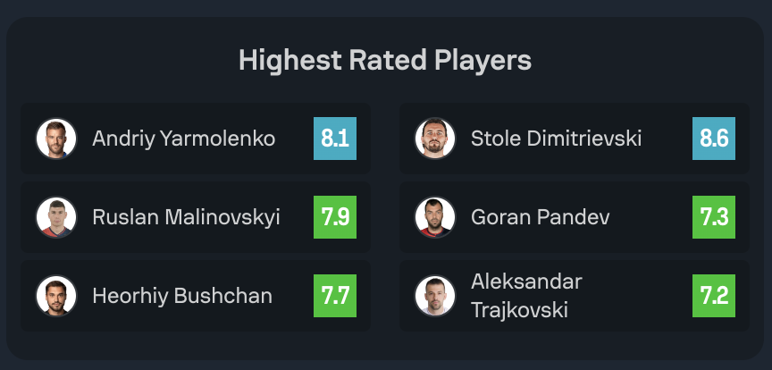

## North Macedonia - Netherlands

```python
mvp(3788770)
```

|  | player | mean_dv |
| --- | --- | --- |
| 0 | Enis Bardhi | -0.559118 |
| 1 | Aleksandar Trajkovski | -0.559879 |
| 2 | Ezgjan Alioski | -0.559916 |
| 3 | Stefan Ristovski | -0.560320 |
| 4 | Stole Dimitrievski | -0.567902 |
| 5 | Denzel Dumfries | -0.568614 |
| 6 | Arijan Ademi | -0.568742 |
| 7 | Steven Berghuis | -0.569449 |
| 8 | Goran Pandev | -0.569819 |
| 9 | Visar Musliu | -0.570174 |
| 10 | Eljif Elmas | -0.570425 |
| 11 | Memphis Depay | -0.573674 |
| 12 | Quincy Anton Promes | -0.574221 |
| 13 | Darko Velkovski | -0.574975 |
| 14 | Ivan Trichkovski | -0.575504 |
| 15 | Georginio Wijnaldum | -0.583066 |
| 16 | Maarten Stekelenburg | -0.583712 |
| 17 | Ryan Gravenberch | -0.583847 |
| 18 | Patrick van Aanholt | -0.585589 |
| 19 | Frenkie de Jong | -0.586953 |
| 20 | Matthijs de Ligt | -0.587512 |
| 21 | Jurriën David Norman Timber | -0.589092 |
| 22 | Stefan de Vrij | -0.592858 |
| 23 | Daley Blind | -0.593003 |
| 24 | Donyell Malen | -0.594688 |

In the [Sofascore match analysis](https://www.sofascore.com/north-macedonia-netherlands/fUbsCVb#id:8602462), Wijnaldum emerges as the MVP, despite our model placing him in 16th position. Interestingly, our predictions for other top players on the Netherlands team contradict the Sofascore ratings. Conversely, our model's predictions for North Macedonia players proved more precise, with Bardhi ranking 1st, rightfully recognized as the best player for his team, and Ristovski securing 4th place, reflecting his standout performance. Notably, Nikolov, although a substitution, didn't accumulate enough actions to be rated by our model.

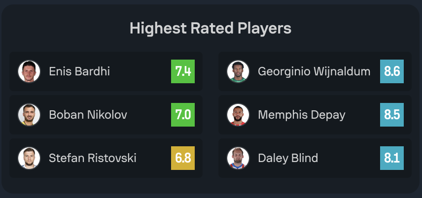

### 4.3 DVs of different potential actions

Here, we select one timestep, belonging to the Ukraine - North Macedonia match, for which we created a set of potential actions that the actor could follow. For each potential action, we computed the DV and we evaluated the validity of the model based on our football knowledge.

```python
possible_actions = np.array([[0,0,0,1,0,100/60-1,27/40-1], #difficult pass
                             [0,0,0,1,0,107/60-1,10/40-1], #slightly through pass
                             [0,0,0,1,0,102/60-1,6/40-1], #normal pass
                             [0,0,0,1,0,102/60-1,25/40-1], #pass to opponent
                             ])
```

```python
iql.predict_value(x = np.tile(state_EURO2020_C[125].reshape(1,4,80,120),(4,1,1,1)), action = possible_actions)
```

```
array([-0.67047   , -0.6699902 , -0.6683903 , -0.67068386], dtype=float32)
```

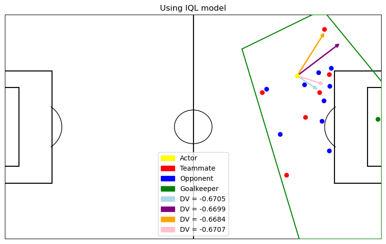

```python
import matplotlib.patches as mpatches
draw_event(df_actions_C.original_event_id.iloc[125])
plt.annotate('', xy=(93.099998,58.200001), xytext=(100, 80-27),
             arrowprops=dict(arrowstyle='<|-', color='lightblue', lw=2))
plt.annotate('', xy=(93.099998,58.200001), xytext=(107, 80-10),
             arrowprops=dict(arrowstyle='<|-', color='purple', lw=2))
plt.annotate('', xy=(93.099998,58.200001), xytext=(102, 80-6),
             arrowprops=dict(arrowstyle='<|-', color='orange', lw=2))
plt.annotate('', xy=(93.099998,58.200001), xytext=(102, 80-25),
             arrowprops=dict(arrowstyle='<|-', color='pink', lw=2))

arrow_handles = [
    mpatches.FancyArrowPatch((0,0), (1,1), color='lightblue', arrowstyle='<|-', label='DV = -0.6705'),
    mpatches.FancyArrowPatch((0,0), (1,1), color='purple', arrowstyle='<|-', label='DV = -0.6699'),
    mpatches.FancyArrowPatch((0,0), (1,1), color='orange', arrowstyle='<|-', label='DV = -0.6684'),
    mpatches.FancyArrowPatch((0,0), (1,1), color='pink', arrowstyle='<|-', label='DV = -0.6707')
]

# Add legend with custom handles and labels
plt.legend(handles=[actor_dot, teammate_dot, opponent_dot, goalkeeper_dot] + arrow_handles)
plt.title('Using IQL model')
plt.show()
```

As we can see the two worst actions that the actor could do are the pink and blue passes. This is aligning with our expectations as these passes are made into an area that is congested with opposition players. Thus, it is likely to result in a loss of possesion. Out of the two best actions, our model tells that the orange pass is the best one. This aligns with what we might expect on a football pitch, since this pass is made straight to the actor's teammate which puts the teammate in the "safest" and closest-to-the-goal possible position to then play the ball.

### 4.4 Goalkeepers analysis

As proposed in Pulis (2023), we focused our analysis on goalkeepers DVs (considering only passes, crosses and dribbles)

```python
gk_analysis = pd.DataFrame(columns = ['GK', 'mean_dv', 'mean_reward'])
for gk in ['Maarten Stekelenburg', 'Stole Dimitrievski', 'Daniel Bachmann', 'Heorhii Bushchan']:
      gk_analysis.loc[len(gk_analysis)] = gk, np.mean(pred[obs_game.player_name == gk]), np.mean(reward_EURO2020_C[obs_game.player_name == gk])
gk_analysis.set_index('GK', inplace = True)
gk_analysis
```

| GK | mean_dv | mean_reward |
| --- | --- | --- |
| Maarten Stekelenburg | -0.561351 | -0.124486 |
| Stole Dimitrievski | -0.556562 | -0.119267 |
| Daniel Bachmann | -0.579134 | -0.130545 |
| Heorhii Bushchan | -0.561449 | -0.135389 |

Comparing the results of the mean DVs and the mean reward for the goalkeepers, we can observe that there is a decent correspondance between the two metrics.

### 4.5 Cross/Pass Analysis

Another analysis proposed by Pulis (2023) is about the correlation between mean DVs for passes and crosses.

```python
pass_analysis = pd.DataFrame(columns = ['player', 'mean_cross', 'mean_pass'])
for player in obs_game.player_name.unique():
    if len(pred[(obs_game.player_name == player) & (pd.DataFrame(action_EURO2020_C).iloc[:,1] == 1)]) > 3:
        pass_analysis.loc[len(pass_analysis)] = player, np.mean(pred[(obs_game.player_name == player) & (pd.DataFrame(action_EURO2020_C).iloc[:,1] == 1)]), \
        np.mean(pred[(obs_game.player_name == player) & (pd.DataFrame(action_EURO2020_C).iloc[:,3] == 1)])

pass_analysis
```

|  | player | mean_cross | mean_pass |
| --- | --- | --- | --- |
| 0 | Stefan Ristovski | -0.587748 | -0.570253 |
| 1 | Ezgjan Alioski | -0.567787 | -0.565056 |
| 2 | Vitalii Mykolenko | -0.585284 | -0.589009 |
| 3 | Oleksandr Karavaev | -0.623570 | -0.574798 |
| 4 | Andriy Yarmolenko | -0.553827 | -0.581880 |
| 5 | Denzel Dumfries | -0.618146 | -0.574915 |
| 6 | Memphis Depay | -0.611917 | -0.575844 |
| 7 | Patrick van Aanholt | -0.580439 | -0.581284 |
| 8 | David Olatukunbo Alaba | -0.574659 | -0.602480 |
| 9 | Stefan Lainer | -0.532180 | -0.571682 |
| 10 | Marcel Sabitzer | -0.573539 | -0.581782 |

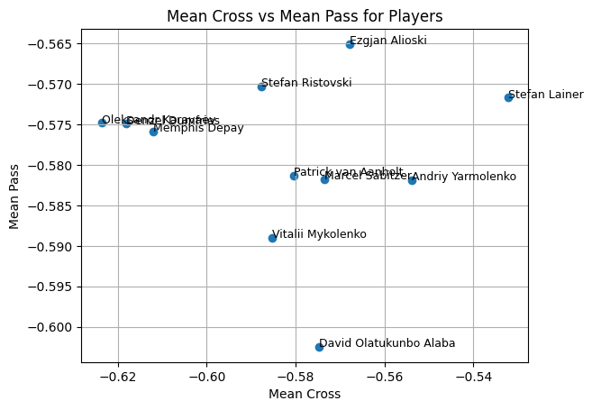

```python
plt.scatter(pass_analysis.mean_cross, pass_analysis.mean_pass)

for index, row in pass_analysis.iterrows():
    plt.text(row['mean_cross'], row['mean_pass'], row['player'], fontsize=9)

# Adding labels and title
plt.xlabel('Mean Cross')
plt.ylabel('Mean Pass')
plt.title('Mean Cross vs Mean Pass for Players')

# Displaying plot
plt.grid(True)
plt.show()
```

We replicated the analysis considering players that have done at least three crosses. From the scatterplot we can observe that data are quite sparse. However, not considering David Alaba, defender of the Austria National team, could lead to the identification of a positive correlation among the two measures.

## 5. Discussion

### 5.1 Interpretation of Results

Our results provide a comprehensive understanding of the limitations and potential of using decision values (DVs) to evaluate performance in football. A significant finding is that DVs do not consistently correlate with team performance. When ranking teams based on their mean DVs across all matches, the ranking was completely reversed compared to the actual group standings at UEFA Euro 2020. Additionally, in four out of six single matches, the mean DVs of the teams did not reflect the final match outcomes. This discrepancy is attributed to two main factors.

Firstly, our limited computational power restricted the training set to six matches, as opposed to the 380 matches used in the referenced paper. Moreover, our model was trained on only 10 epochs, whereas the reference model utilized 700 epochs. These limitations significantly impacted the robustness and generalizability of our model.

Secondly, it is crucial to understand that DVs are not direct predictors of team performance or match outcomes. Instead, DVs represent the expected return of a specific action, indicating how likely an action is to lead to future possession loss or retention. Therefore, players who can anticipate the "long-term" impact of their actions are rewarded by our model.

Despite these limitations, some results validate the model's capability to identify good decision-makers. The analysis of the Most Valuable Player (MVP) of the match suggests that our model can recognize players making better decisions. However, the performance metric used for comparison needs further investigation, and there is a slight positive bias towards North Macedonian players affecting the overall results.

The goalkeeper and cross/pass analyses align with the findings in the referenced paper. DVs can serve as effective performance metrics for goalkeepers, considering only "feet" touches, as they are closely linked to rewards. Similarly, players who consistently make optimal decisions for crosses and passes can be identified, indicating that DVs can differentiate better decision-makers among players who frequently engage in these actions.

Lastly, the results regarding potential actions are consistent with our expectations. The highest DVs were assigned to the most "obvious" passes, while more challenging actions, leading to disadvantageous situations in the next time step, received lower values. This suggests that the model can evaluate the quality of decisions based on their potential outcomes.

### 5.2 Limitations and Further Research

Our research faced significant constraints due to the limited number of episodes in our training data, primarily caused by computational limitations. Attempts to train on larger datasets resulted in frequent kernel crashes, hindering the robustness and scalability of our model.

Future research can build on our groundwork by creating an environment that allows for the effective testing of the policies generated by our model. This environment will be essential for developing and refining policies tailored to football matches, enabling iterative improvements through online learning.

An important enhancement to our methodology involves integrating our model with an API that provides data on players' dominant foot. This addition would allow for a more detailed analysis of shot and pass accuracy based on player position and dominant foot, which are critical factors for successful outcomes.

Additionally, expanding the action space of our model could improve its decision-making capabilities. For example, allowing the agent to choose to remain in position would enable teammates to make strategic runs into the box. This modification would change the state space from one with limited passing options to one with potentially better opportunities, improving the overall decision-making process.

## 6. Conclusion

This study sought to leverage Deep Reinforcement Learning (DRL) to objectively evaluate football player decisions within the context of a match, inspired by Pulis (2023). By developing a Decision Value (DV) model, we aimed at thoroughly exploring a more nuanced and contextually aware metric for assessing player performance compared to traditional statistics. Despite significant computational constraints, our findings demonstrate both the potential and the limitations of using DVs in football analysis.

Our research revealed that while DVs are not consistently correlated with team performance or match outcomes, they do provide valuable insights into individual decision-making. The inconsistency in team performance ranking based on DVs, and the limited correlation between DVs and match results, highlight the challenges posed by our restricted dataset and limited training epochs. These constraints hindered the robustness and generalizability of our model, underscoring the importance of extensive training data and computational power in DRL applications.

Importantly, our model showed promise in identifying players who make better decisions, as evidenced by the MVP analysis and the alignment with goalkeeper and cross/pass evaluations. The analysis indicated that DVs could effectively differentiate between good and poor decision-makers among players frequently involved in critical actions such as passes and crosses. Additionally, the goalkeeper analysis confirmed that DVs could serve as a reliable metric for evaluating performance in specific scenarios.

Despite the encouraging results, several limitations need to be addressed in future research. The limited number of episodes in our training data due to computational constraints significantly impacted our model's effectiveness. Future work should focus on scaling the dataset and increasing the training epochs to enhance the model's robustness and generalizability.

Moreover, integrating additional data, such as players' dominant foot information, could refine the analysis of shot or pass accuracy, providing a more granular understanding of decision-making. Expanding the action space to include more tactical options, such as player positioning and movement, could further improve the model's ability to simulate realistic football scenarios.

In conclusion, while our study demonstrates the potential of DRL in evaluating football player decisions, it also highlights the necessity for robust datasets, substantial computational resources, and further methodological enhancements. By addressing these challenges, future research can build on our work to develop more accurate and insightful tools for football analysis, ultimately contributing to a deeper understanding of the game and player performance.

## 7. References

[1] - K. Singh, “Introducing Expected Threat (xT),” 2018. [Online]. Available: https://karun.in/ blog/expected-threat.html

[2] - Pulis, M. (2023). Deep Reinforcement Learning for Football Player Decision Analysis. University of Malta. Retrieved from https://www.um.edu.mt/library/oar/handle/123456789/12345

[3] - Chia, R. (1994). The Concept of Decision: A Deconstructive Analysis. Journal of Management Studies, 31(5), 781-806.

[4] - Gréhaigne, J.-F., Richard, J.-F., & Griffin, L. L. (2012). Teaching and learning team sports and games. Routledge.

[5] - Vaeyens, R., Lenoir, M., Williams, A. M., & Philippaerts, R. M. (2007). Talent identification and development programmes in sport: Current models and future directions. Sports Medicine, 37(9), 703-714.

[6] - Woods, C. T., Raynor, A. J., Bruce, L., & McDonald, Z. (2015). The use of skill tests to predict status in junior Australian football. Journal of Sports Sciences, 33(11), 1132-1140.

[7] - Pizarro, D., Mascret, N., Brondino, M., & Cury, F. (2019). How players in a team sport dynamically perform shared goals: Insights from a collective approach. Frontiers in Psychology, 10, 2415.

[8] - Rein, R., & Memmert, D. (2016). Big data and tactical analysis in elite soccer: Future challenges and opportunities for sports science. SpringerPlus, 5, 1410.

[9] - García-Aliaga et al. Comparative Analysis of Soccer Performance Intensity of the Pre–Post-Lockdown COVID-19 in LaLiga™. International Journal of Environmental Research and Public Health, 18(3685), 999.

[10] - Kusmakar, S., Shelyag, S., Zhu, Y., Dwyer, D., Gastin, P., & Angelova, M. (2020). Machine learning enabled team performance analysis in the dynamical environment of soccer. IEEE Access, 8, 90266-90279.

[11] - Liu, G. and Schulte, O. (2018) ‘Deep reinforcement learning in ice hockey for context-aware player evaluation’, Proceedings of the Twenty-Seventh International Joint Conference on Artificial Intelligence

[12] - Yanai, C. et al. (2022) ‘Q-Ball: Modeling Basketball Games using deep reinforcement learning’, Proceedings of the AAAI Conference on Artificial Intelligence, 36(8), pp. 8806–8813.

[13] - Riedmiller, M., Gabel, T., Hafner, R., & Lange, S. (2018). Reinforcement Learning for Robot Soccer. In 2018 IEEE/RSJ International Conference on Intelligent Robots and Systems (IROS) (pp. 1-7). IEEE.

[14] - Duan, Y., Kurach, K., Xu, X., Xie, E., Gorbach, M., Pechenko, A., ... & Szepesvári, C. (2019). Google Research Football: A Novel Reinforcement Learning Environment. arXiv preprint arXiv:1907.11180.

[15] - Rahimian, P. and Toka, L. (2023) ‘A data-driven approach to assist offensive and defensive players in Optimal Decision making’, International Journal of Sports Science & Coaching, 19(1), pp. 245–256.

[16] - R. J. Williams, “Simple statistical gradient-following algorithms for connectionist reinforcement learning,” Machine Learning, vol. 8, no. 3, pp. 229–256, 1992.

[17] - Nair, A., Gupta, A., Dalal, M., & Levine, S. (2020). AWAC: Accelerating Online Reinforcement Learning with Offline Datasets arXiv preprint arXiv:2006.09359, 2020.

[18] - Kostrikov, I., Nair, A., & Levine, S. (2021). Offline Reinforcement Learning with Implicit Q-Learning arXiv preprint arXiv:2110.06169

[19]- d3rlpy : An offline deep reinforcement learning library (2024) https://d3rlpy.readthedocs.io/en/v2.5.0/.

[20] - socceraction 1.5.1 Convert soccer event stream data to SPADL and value player actions using VAEP or xT (2024). https://socceraction.readthedocs.io/en/latest/index.html.